# VSE Simulation — standalone notebook

This notebook reproduces the **Voter Satisfaction Efficiency (VSE)** simulation methodology from the [`vse-sim`](https://github.com/electionscience/vse-sim) project for five voting systems — Plurality, Approval, IRV, STAR, and Condorcet (Schulze only; Ranked Pairs is dropped) — and extends it with three new sources of realistic voter degradation (epistemic noise, unfamiliarity, and ballot fatigue) and two new top-2 runoff hybrid methods (Approval Top 2 and Plurality Top 2).

## How this notebook is organized

The notebook proceeds in four parts: **(1)** a vendored, unmodified copy of the `vse-sim` methodology and the five baseline voting methods (Section 1); **(2)** the three new degradation mechanisms — epistemic noise and participation friction (unfamiliarity + ballot fatigue) — plus the two new top-2 runoff hybrid methods (Approval Top 2 and Plurality Top 2, each simulated with a Groggy and a Clear-Eyed runoff variant); **(3)** the simulation loop, baseline results, and a sanity check against `vse-sim`'s own published numbers; **(4)** the sweeps and diagnostics that produce this notebook's findings — individual and joint parameter sweeps, the runoff information-quality sweep, and the per-election runoff-betrayal diagnostic.

## 1. Vendored library

The code below is copied, with one small addition, from the `vse_sim` Python package at electionscience/vse-sim: the `Method` base class and VSE formula, the electorate/voter models needed for the "kitchen sink" (`KSModel`) model used for every published VSE number, the strategic-voting and media-noise machinery, and the 5 baseline voting methods. Anything only needed by voting methods this notebook doesn't use (Ranked Pairs, Majority Judgment, Borda, 3-2-1, IRNR, ...) is omitted.

### 1.1 Setup: shared imports

```python
import random
import math
import time
from collections import defaultdict

import numpy as np
import matplotlib.pyplot as plt
from matplotlib.lines import Line2D
from IPython.display import Markdown, display
```

### 1.2 Utility decorators (from `decorators.py`)

```python
from functools import update_wrapper, wraps
from inspect import getfullargspec, isfunction
from itertools import starmap


def decorator(d):
    """Make function d a decorator: d wraps a function fn."""
    def _d(fn):
        return update_wrapper(d(fn), fn)
    return _d
decorator = decorator(decorator)(decorator)


@decorator
def autoassign(*names, **kwargs):
    """
    autoassign(function) -> method
    autoassign(*argnames) -> decorator
    autoassign(exclude=argnames) -> decorator.

    Lets a method assign (some of) its arguments as attributes of ``self``
    automatically -- used throughout below instead of writing out
    ``self.x = x`` for every constructor argument.
    """
    if kwargs:
        exclude, f = set(kwargs['exclude']), None
        def sieve(values):
            return filter(lambda nv: nv[0] not in exclude, values)
    elif len(names) == 1 and isfunction(names[0]):
        f = names[0]
        def sieve(values):
            return values
    else:
        names, f = set(names), None
        def sieve(values):
            return [nv for nv in values if nv[0] in names]
    def decorator(f):
        spec = getfullargspec(f)
        fargnames, fdefaults = spec.args, spec.defaults
        fargnames, fdefaults = fargnames[1:], fdefaults or ()
        defaults = list(sieve(zip(reversed(fargnames), reversed(fdefaults), strict=False)))
        @wraps(f)
        def decorated(self, *args, **kwargs):
            assigned = dict(sieve(zip(fargnames, args, strict=False)))
            assigned.update(sieve(kwargs.items()))
            for _ in starmap(assigned.setdefault, defaults):
                pass
            self.__dict__.update(assigned)
            return f(self, *args, **kwargs)
        return decorated
    return f and decorator(f) or decorator


_missing = object()

@decorator
class cached_property(object):
    """Converts a function into a lazy property: computed once, then cached
    on the instance's own __dict__."""

    def __init__(self, func, name=None, doc=None):
        self.__name__ = name or func.__name__
        self.__module__ = func.__module__
        self.__doc__ = doc or func.__doc__
        self.func = func

    def __get__(self, obj, type=None):
        if obj is None:
            return self
        value = obj.__dict__.get(self.__name__, _missing)
        if value is _missing:
            value = self.func(obj)
            obj.__dict__[self.__name__] = value
        return value
```

### 1.3 Core: `Method` base class & VSE formula (from `core.py`)

`Method` is the shared base every voting method below subclasses. `normalized_vse` is the VSE formula this notebook reports throughout: `vse = (util - rand) / (best - rand)`, where `best`/`rand` are the electorate's true mean social utility for the best and a random candidate.

`resultsTable`/`vseOn` accept an optional `scoring_voters` electorate: when ballots are cast on a *perceived* (possibly noisy) electorate but VSE should be scored against *true* utilities, the true electorate is passed as `scoring_voters` (Section 2).

```python
from dataclasses import dataclass, field

from numpy import isclose, mean


def isnum(x):
    """Test whether an object is an instance of a built-in numeric type."""
    return next((1 for T in (int, float, complex) if isinstance(x, T)), 0)


class VseOneRun:
    @autoassign
    def __init__(self, result, tallyItems, strat):
        pass


class VseMethodRun:
    @autoassign
    def __init__(self, method, choosers, results):
        pass


@dataclass
class ElectionContext:
    """Mutable metadata scoped to one method instance and election."""
    extra_events: dict = field(default_factory=dict)


def normalized_vse(utility, best, random_baseline):
    """Normalize utility to VSE.

    When every candidate has the same social utility there is no possible
    improvement over random selection, so every method receives neutral VSE.
    """
    denominator = best - random_baseline
    if isclose(denominator, 0):
        return 0.0
    return (utility - random_baseline) / denominator


class SideTally(defaultdict):
    """Tracks how many voters are being strategic, etc.

    DO NOT use plain +; for this class it is equivalent to +=, but less readable.
    """
    def __init__(self):
        super().__init__(int)
        self._keys_initialized = False

    def initKeys(self, chooser):
        if self._keys_initialized:
            return
        try:
            self.keyList = chooser.allTallyKeys()
        except AttributeError:
            try:
                self.keyList = list(chooser)
            except TypeError:
                pass
        self._keys_initialized = True

    def serialize(self):
        try:
            return [self[key] for key in self.keyList]
        except AttributeError:
            return []

    def fullSerialize(self):
        try:
            return ([self[key] for key in self.keyList] +
                    [self[key] for key in self.keys() if key not in self.keyList])
        except AttributeError:
            return [self[key] for key in self.keys()]

    def itemList(self):
        try:
            kl = self.keyList
            return ([(k, self[k]) for k in kl] +
                    [(k, self[k]) for k in self.keys() if k not in kl])
        except AttributeError:
            return list(self.items())


class Tallies(list):
    """Used (ONCE) as an enumerator: gives an inexhaustible flow of SideTally
    objects. After that, use as a list to see those objects."""
    def __iter__(self):
        if hasattr(self, "used"):
            return super().__iter__()
        self.used = True
        return self

    def __next__(self):
        tally = SideTally()
        self.append(tally)
        return tally


class Method:
    """Base class for election methods. Holds some of the duct tape."""

    def __init__(self):
        self.context = ElectionContext()

    @property
    def extraEvents(self):
        """Compatibility view of metadata for this method's current election."""
        return self.context.extra_events

    @extraEvents.setter
    def extraEvents(self, value):
        self.context.extra_events = value

    def __str__(self):
        return self.__class__.__name__

    def results(self, ballots, **kwargs):
        """Combines ballots into results. Override for comparative methods."""
        if type(ballots) is not list:
            ballots = list(ballots)
        return list(map(self.candScore, zip(*ballots, strict=False)))

    @staticmethod  # cls is provided explicitly, not through binding
    def honBallot(cls, utils):
        """Takes utilities and returns an honest ballot."""
        raise NotImplementedError(f"{cls} needs honBallot")

    @staticmethod
    def winner(results):
        """Find the winner once scores are already calculated. Override for
        ranked methods."""
        winScore = max(result for result in results if isnum(result))
        winners = [cand for (cand, score) in enumerate(results) if score == winScore]
        return random.choice(winners)

    def honBallotFor(self, voters):
        """This is where you'd do any setup necessary and create an honBallot
        function. The base version just returns honBallot."""
        return self.honBallot

    def dummyBallotFor(self, polls):
        return lambda cls, utilities, stratTally: utilities

    def resultsFor(self, voters, chooser, tally=None, **kwargs):
        """Create ballots and get results."""
        if tally is None:
            tally = SideTally()
        tally.initKeys(chooser)
        return dict(results=self.results([chooser(self.__class__, voter, tally)
                                  for voter in voters],
                              **kwargs),
                chooser=chooser.__name__,
                tally=tally)

    def multiResults(self, voters, chooserFuns=(), media=(lambda x, t: x),
                checkStrat=True):
        """Runs the honest election, then the strategic election (based on the
        honest results filtered through media), then one-sided-strategic,
        'smart' one-sided, and any caller-supplied chooserFuns."""
        honTally = SideTally()
        self.context = ElectionContext()
        hon = self.resultsFor(voters, self.honBallotFor(voters), honTally, isHonest=True)

        stratTally = SideTally()
        polls = media(hon["results"], stratTally)
        winner, _w, target, _t = self.stratTargetFor(sorted(enumerate(polls), key=lambda x: -x[1]))

        strat = self.resultsFor(voters, self.stratBallotFor(polls), stratTally)

        ossTally = SideTally()
        oss = self.resultsFor(voters, self.ballotChooserFor(OssChooser()), ossTally)
        ossWinner = oss["results"].index(max(oss["results"]))
        ossTally["worked"] += (1 if ossWinner == target else
                                    (0 if ossWinner == winner else -1))

        smart = dict(results=(hon["results"] if ossTally["worked"] == 1 else oss["results"]),
                chooser="smartOss",
                tally=SideTally())

        extraTallies = Tallies()
        results = ([strat, oss, smart] +
                [self.resultsFor(voters, self.ballotChooserFor(chooserFun), aTally)
                    for (chooserFun, aTally) in zip(chooserFuns, extraTallies, strict=False)]
                  )
        return ([(hon["results"], hon["chooser"], list(self.extraEvents.items()))] +
                [(r["results"], r["chooser"], r["tally"].itemList()) for r in results])
```

```python
    def vseOn(self, voters, chooserFuns=(), scoring_voters=None, perceived_voters=None,
              genuine_sets=None, aware_sets=None, primary_awareness_alpha=None, **args):
        """Finds honest and strategic VSE for this method on the given electorate.

        `scoring_voters` -- CHECKPOINT-2 ADDITION, not in the original: the
        electorate whose socUtils defines ground truth for VSE scoring.
        Defaults to `voters` (the original behavior) when not given -- pass a
        separate true electorate here when `voters` is a noisy *perceived*
        electorate (see make_perceived_electorate below), so ballots are cast
        on perception while VSE is still scored against ground truth.

        `perceived_voters` -- the primary's own perceived electorate (post-epistemic-noise,
        pre-participation-friction), i.e. `voters` before apply_participation_friction ran on
        it. Exposed for Top2Base's runoff_t=None case, which needs the primary's noise
        level without its friction baked in -- see Top2Base._runoff_electorate above.

        `genuine_sets` -- the per-voter genuinely-evaluated candidate sets returned alongside
        `voters` by apply_participation_friction (None if friction wasn't applied). Every method
        except Irv ignores this; Irv.honBallotFor reads it for honest-ballot exhaustion.

        `aware_sets` -- like `genuine_sets` but ignoring fatigue: the per-voter candidates the
        voter actually RECOGNIZED (awareness lottery only), always a superset of `genuine_sets`
        for the same voter. Every method except Top2Base's `runoff_coma=True` option ignores
        this; Coma reuses it directly to build the runoff electorate with no new randomness
        drawn -- see Top2Base._runoff_electorate and apply_participation_friction above.

        `primary_awareness_alpha` -- the raw `awareness_alpha` value used to build this election's
        ballot electorate (a number, not an electorate). No method currently reads this for
        runoff purposes -- Top2Base's `runoff_coma=True` option used to reapply friction fresh at
        this rate, but now reuses `aware_sets` (above) directly instead, with no new randomness.
        Kept threaded through in case a future runoff variant needs the raw rate rather than a
        realized outcome.
        """
        truth_voters = voters if scoring_voters is None else scoring_voters  # <-- checkpoint 2
        self._scoring_voters = truth_voters  # <-- checkpoint 3: exposed for Top2Base's clear-eyed-runoff option.
        self._perceived_voters = perceived_voters
        self._genuine_sets = genuine_sets
        self._aware_sets = aware_sets
        self._primary_awareness_alpha = primary_awareness_alpha
        # Must be set BEFORE multiResults() runs -- results() (called from deep inside
        # multiResults, via resultsFor) reads self._scoring_voters for this same election;
        # setting it after multiResults() returns would leave results() reading the PREVIOUS
        # election's true electorate (or None, on the very first call).
        multiResults = self.multiResults(voters, chooserFuns, **args)
        utils = truth_voters.socUtils
        best = max(utils)
        rand = mean(utils)

        vses = VseMethodRun(
            self.__class__,
            chooserFuns,
            [
                VseOneRun(
                    [normalized_vse(utils[self.winner(result)], best, rand)],
                    tally,
                    chooser,
                )
                for result, chooser, tally in multiResults
            ],
        )
        vses.extraEvents = dict(self.extraEvents)
        return vses

    def resultsTable(self, eid, emodel, cands, voters, chooserFuns=(), scoring_voters=None,
                      perceived_voters=None, genuine_sets=None, aware_sets=None,
                      primary_awareness_alpha=None, **args):
        """As vseOn, but returns one CSV-row-shaped dict per chooser.
        See vseOn above for what `scoring_voters`, `perceived_voters`, `genuine_sets`,
        `aware_sets`, and `primary_awareness_alpha` do.
        """
        truth_voters = voters if scoring_voters is None else scoring_voters  # <-- checkpoint 2
        self._scoring_voters = truth_voters  # <-- checkpoint 3: exposed for Top2Base's clear-eyed-runoff option.
        self._perceived_voters = perceived_voters
        self._genuine_sets = genuine_sets
        self._aware_sets = aware_sets
        self._primary_awareness_alpha = primary_awareness_alpha
        # Must be set BEFORE multiResults() runs -- see the identical note in vseOn above.
        multiResults = self.multiResults(voters, chooserFuns, **args)
        utils = truth_voters.socUtils
        best = max(utils)
        rand = mean(utils)
        rows = []
        nvot = len(voters)
        for (result, chooser, tallyItems) in multiResults:
            winner = self.winner(result)
            utility = utils[winner]
            row = {
                "eid": eid,
                "emodel": emodel,
                "ncand": cands,
                "nvot": nvot,
                "best": best,
                "rand": rand,
                "method": str(self),
                "chooser": chooser,
                "winner": winner,  # checkpoint-4 addition: ground-truth Condorcet efficiency
                                   # needs to know which candidate a method actually elected.
                "util": utility,
                "vse": normalized_vse(utility, best, rand),
            }
            for (i, (k, v)) in enumerate(tallyItems):
                row[f"tallyName{str(i)}"] = str(k)
                row[f"tallyVal{str(i)}"] = str(v)
            rows.append(row)
        return rows

    @staticmethod
    def ballotChooserFor(chooserFun):
        """Takes a chooserFun; returns a ballot chooser using that chooserFun."""
        def ballotChooser(cls, voter, tally):
            return getattr(voter, f"{cls.__name__}_{chooserFun(cls, voter, tally)}")
```

```python
        ballotChooser.__name__ = chooserFun.getName()
        return ballotChooser

    def stratTarget2(self, places):
        ((frontId, frontResult), (targId, targResult)) = places[:2]
        return (frontId, frontResult, targId, targResult)

    def stratTarget3(self, places):
        ((frontId, frontResult), (targId, targResult)) = places[:3:2]
        return (frontId, frontResult, targId, targResult)

    stratTargetFor = stratTarget2

    def stratBallotFor(self, polls):
        """Returns a (function which takes utilities and returns a strategic
        ballot) for the given 'polling' info."""
        places = sorted(enumerate(polls), key=lambda x: -x[1])  # high to low
        (frontId, frontResult, targId, targResult) = self.stratTargetFor(places)
        n = len(polls)
        @rememberBallots
        def stratBallot(cls, voter):
            stratGap = voter[targId] - voter[frontId]
            ballot = [0] * len(voter)
            isStrat = stratGap > 0
            extras = cls.fillStratBallot(voter, polls, places, n, stratGap, ballot,
                                frontId, frontResult, targId, targResult)
            result = dict(strat=ballot, isStrat=isStrat, stratGap=stratGap)
            if extras:
                result.update(extras)
            return result
        return stratBallot


@decorator
def rememberBallot(fun):
    """Decorator for a function xxxBallot(cls, voter) which memoizes the vote
    onto the voter in an attribute named <methName>_xxx."""
    def getAndRemember(cls, voter, tally=None):
        ballot = fun(cls, voter)
        setattr(voter, f"{cls.__name__}_{fun.__name__[:-6]}", ballot)
        return ballot

    getAndRemember.__name__ = fun.__name__
    getAndRemember.allTallyKeys = lambda: []
    return getAndRemember


@decorator
def rememberBallots(fun):
    """As rememberBallot, but fun returns a dict of {ballotType: ballot}."""
    def getAndRemember(cls, voter, tally=None):
        ballots = fun(cls, voter)
        for bType, ballot in ballots.items():
            setattr(voter, f"{cls.__name__}_{bType}", ballot)
        return ballots[fun.__name__[:-6]]  # leave off the "...Ballot"

    getAndRemember.__name__ = fun.__name__
    getAndRemember.allTallyKeys = lambda: []
    return getAndRemember


class CandidateWithCount:
    def __init__(self, c=[], v=0):
        self.candidate = c
        self.votes = v
```

### 1.4 Voter models (from `voter_models.py`, trimmed to what `KSModel` needs)

`KSModel` ("kitchen sink") is the hierarchical-cluster electorate model used to generate every published VSE number in the original project: issue dimensions are grouped into nested "issue clusters," voters are assigned to per-cluster "identity clusters" via a Chinese-restaurant process, and each identity cluster has its own mean position and caring level. `RandomModel` is also included below (needed as `KSModel`'s own base electorate) — it's the simpler "Impartial Culture" model (independent random utilities) if you want to compare against it.

```python
from numpy import mean
from numpy.lib.scimath import sqrt
from scipy.stats import beta


class Voter(tuple):
    """A tuple of candidate utilities."""

    def __new__(cls, utilities=()):
        return super().__new__(
            cls, (utility.item() if hasattr(utility, "item") else utility for utility in utilities)
        )

    @classmethod
    def rand(cls, ncand):
        """Create a random voter with an independent standard normal utility
        for each candidate."""
        return cls(random.gauss(0, 1) for _ in range(ncand))

    def hybridWith(self, v2, w2):
        """Create a weighted average of two voters. The weight of self is
        always 1; w2 is v2's weight relative to that. If both are standard
        normal to start with, the result will be standard normal too."""
        assert len(self) == len(v2)
        return self.copyWithUtils((self[i] / sqrt(1 + w2 ** 2)) +
                                    (w2 * v2[i] / sqrt(1 + w2 ** 2))
                                 for i in range(len(self)))

    def copyWithUtils(self, utils):
        """Create a new voter with attrs as self and given utils."""
        return self.__class__(utils)

    def mutantChild(self, muteWeight):
        """Returns a copy hybridized with a random voter of weight muteWeight."""
        return self.hybridWith(self.__class__.rand(len(self)), muteWeight)


class PersonalityVoter(Voter):

    cluster_count = 0

    def __init__(self, *args, **kw):
        super().__init__()
        self.cluster = self.__class__.cluster_count
        self.__class__.cluster_count += 1
        self.personality = random.gauss(0, 1)

    @classmethod
    def resetClusters(cls):
        cls.cluster_count = 0

    def copyWithUtils(self, utils):
        voter = super().copyWithUtils(utils)
        voter.copyAttrsFrom(self)
        return voter

    def copyAttrsFrom(self, model):
        self.personality = model.personality
        self.cluster = model.cluster


class Electorate(list):
    """A list of voters. Each voter is a list of candidate utilities."""
    @cached_property
    def socUtils(self):
        """Mean utility across the electorate for each candidate: the
        candidates' social utilities."""
        return [value.item() for value in map(mean, zip(*self, strict=False))]


class RandomModel:
    """Electorate factory implementing 'Impartial Culture': every voter gets
    an independent random utility for each candidate."""

    def __str__(self):
        return self.__class__.__name__

    def __call__(self, nvot, ncand, vType=PersonalityVoter):
        return Electorate(vType.rand(ncand) for _ in range(nvot))


class DimVoter(PersonalityVoter):
    """A voter in an n-dimensional ideology model."""

    @classmethod
    def fromDims(cls, v, e, caring=None):
        if caring is None:
            caring = [1] * len(v)
            totCaring = e.totWeight
        else:
            totCaring = sum((c * w) ** 2 for c, w in zip(caring, e.dimWeights, strict=False))
        me = cls(-sqrt(
            sum(((vd - cd) * w * cares) ** 2
                for (vd, cd, w, cares) in zip(v, c, e.dimWeights, caring, strict=False)) /
                            totCaring)
          for c in e.cands)
        me.copyAttrsFrom(v)
        me.dims = v
        me.elec = e
        return me


class DimElectorate(Electorate):

    def asDims(self, v, *args):
        return v

    def fromDims(self, dimvoters, vType):
        for v in dimvoters:
            self.append(vType.fromDims(v, self))

    def calcTotWeight(self):
        self.totWeight = sum(w ** 2 for w in self.dimWeights)


class DimModel(RandomModel):
    """N-dimensional ideology model: voters and candidates each get a
    position in n-dimensional space; utility falls off with distance."""

    builtElectorate = DimElectorate

    @autoassign
    def __init__(self, ndims=3, dimWeights=None, baseElectorate=RandomModel()):
        if self.dimWeights is None:
            self.dimWeights = [2 ** (-n) for n in range(ndims)]
        assert len(self.dimWeights) == self.ndims

    def __call__(self, nvot, ncand, vType=DimVoter):
        elec = self.builtElectorate()
        elec.dimWeights = self.dimWeights
        return self.makeElectorate(elec, nvot, ncand, vType)

    def makeElectorate(self, elec, nvot, ncand, vType):
        elec.calcTotWeight()
        votersncands = self.baseElectorate(nvot + ncand, len(elec.dimWeights), vType)
        elec.base = [elec.asDims(v, i) for i, v in enumerate(votersncands[:nvot])]
        elec.cands = [elec.asDims(v, nvot + i) for i, v in enumerate(votersncands[nvot:])]
        elec.fromDims(elec.base, vType)
        return elec


def rbeta(a, b):
    return lambda: beta.rvs(a, b)


class KSElectorate(DimElectorate):

    def chooseClusters(self, n, alpha, caring):
        self.clusters = []
        for i in range(n):
            item = []
            for c in range(self.numClusters):
                r = (i + alpha) * random.random()
                if r > i:
                    item.append(self.numSubclusters[c])
                    self.numSubclusters[c] += 1
                else:
                    item.append(self.clusters[int(r)][c])
            self.clusters.append(item)
        self.clusterMeans = []
        self.clusterCaring = []
        for c in range(self.numClusters):
            subclusterMeans = []
            subclusterCaring = []
            for _ in range(self.numSubclusters[c]):
                cares = caring()
                subclusterMeans.append(
                    [random.gauss(0, sqrt(cares)) for _ in range(self.dcs[c])]
                )
                subclusterCaring.append(caring())
            self.clusterMeans.append(subclusterMeans)
            self.clusterCaring.append(subclusterCaring)

    def asDims(self, v, i):
        result = []
        cares = []
        for dim, c in enumerate(range(self.numClusters)):
            clusterMean = self.clusterMeans[c][self.clusters[i][c]]
            for m in clusterMean:
                acare = self.clusterCaring[c][self.clusters[i][c]]
                result.append(m + (v[dim] * sqrt(1 - acare)))
                cares.append(acare)
        v = PersonalityVoter(result)
        v.cares = cares
        return v

    def fromDims(self, dimvoters, vType):
        for v in dimvoters:
            self.append(vType.fromDims(v, self, v.cares))


class KSModel(DimModel):  # "Kitchen sink": hierarchical-cluster voter model
    """The hierarchical-cluster ('kitchen sink') voter model used for every
    published VSE number in this project."""

    builtElectorate = KSElectorate
    baseElectorate = RandomModel()

    @autoassign
    # dc = dimensional cluster; wc = within-cluster dimension
    def __init__(self, dcdecay=(1, 1), dccut=.2,
            wcdecay=(1, 1), wccut=.2,
            wcalpha=1, vccaring=(3, 1.5)):
        pass

    def __str__(self):
        return "_".join(str(x) for x in (self.__class__.__name__, self.wcalpha) + self.dcdecay + self.wcdecay + self.vccaring)

    def __call__(self, nvot, ncand, vType=DimVoter):
        vType.resetClusters()
        e = self.builtElectorate()
        e.dcs = []
        e.dimWeights = []
        clusterWeight = 1
        while clusterWeight > self.dccut:
            dimweight = clusterWeight
            dimnum = 0
            while dimweight > self.wccut:
                e.dimWeights.append(dimweight)
                dimnum += 1
                dimweight *= beta.rvs(*self.wcdecay)
            e.dcs.append(dimnum)
            clusterWeight *= beta.rvs(*self.dcdecay)
        e.numClusters = len(e.dcs)
        e.numSubclusters = [0] * e.numClusters
        e.chooseClusters(nvot + ncand, self.wcalpha, lambda: beta.rvs(*self.vccaring))
        return self.makeElectorate(e, nvot, ncand, vType)
```

### 1.5 Strategies: choosers & media noise (from `strategies.py`)

`Chooser`s decide which of a voter's already-computed ballots (honest, strategic, ...) actually gets cast — e.g. `ProbChooser` makes a fixed fraction of voters strategic at random; `OssChooser` implements "one-sided strategy" (only voters who prefer the runner-up strategize). Media functions (`fuzzyMediaFor`, etc.) model imperfect *polling* information — a different kind of uncertainty than the epistemic noise added in Section 2 below (see the note there).

```python
from math import isclose as _math_isclose  # aliased: numpy.isclose is already bound to `isclose` above


class Chooser:
    """Choosers pick which of a voter's already-computed ballots (honest,
    strategic, ...) to actually cast."""
    tallyKeys = []

    @autoassign
    def __init__(self, choice, subChoosers=None):
        pass

    def getName(self):
        if hasattr(self, "choice"):  # only true for the base class
            return self.choice
        if not hasattr(self, "name") or not self.name:
            self.name = self.__class__.__name__[:-7]  # drop "Chooser"
        return self.name

    def __call__(self, cls, voter, tally):
        return self.choice

    def addTallyKeys(self, tally):
        for key in self.allTallyKeys:
            tally[key] = 0

    @cached_property
    def myKeys(self):
        prefix = f"{self.getName()}_"
        return [prefix + key for key in self.tallyKeys]

    @cached_property
    def allTallyKeys(self):
        keys = self.myKeys
        for subChooser in self.subChoosers:
            keys += subChooser.allTallyKeys
        return keys

    @cached_property
    def __name__(self):
        return self.__class__.__name__


beHon = Chooser("hon")
beStrat = Chooser("strat")
beX = Chooser("extraStrat")


class LazyChooser(Chooser):
    """Honest, if honest and strategic ballots are the same. Otherwise,
    extra-strategic."""
    tallyKeys = [""]

    @autoassign
    def __init__(self, subChoosers=None):
        if self.subChoosers is None:
            self.subChoosers = [beHon, beX]

    def __call__(self, cls, voter, tally):
        if getattr(voter, f"{cls.__name__}_hon") == getattr(voter, f"{cls.__name__}_strat"):
            tally[self.myKeys[0]] += 0
            return self.subChoosers[0](cls, voter, tally)
        tally[self.myKeys[0]] += 1
        return self.subChoosers[1](cls, voter, tally)


class OssChooser(Chooser):
    """One-sided strategy: strategic ballot for voters who prefer the
    strategic target, honest ballot for voters who prefer the honest
    winner."""
    tallyKeys = ["", "gap"]

    @autoassign
    def __init__(self, subChoosers=None):
        if self.subChoosers is None:
            self.subChoosers = [beHon, beStrat]

    def __call__(self, cls, voter, tally):
        hon, strat = self.subChoosers
        if not getattr(voter, f"{cls.__name__}_isStrat", False):
            return hon(cls, voter, tally) if callable(hon) else hon
        tally[self.myKeys[0]] += 1
        tally[self.myKeys[1]] += getattr(voter, f"{cls.__name__}_stratGap", 0)
        return strat(cls, voter, tally) if callable(strat) else strat

    def getName(self):
        baseName = super(OssChooser, self).getName()
        return f"{baseName}." + "_".join(s.getName() for s in self.subChoosers) + "."


class ProbChooser(Chooser):
    """A fixed fraction of voters (independently, at random) cast the
    strategic (or extra-strategic) ballot; the rest are honest."""

    @autoassign
    def __init__(self, probs):
        if not probs:
            raise ValueError("ProbChooser requires at least one choice")
        if any(probability < 0 for probability, _chooser in probs):
            raise ValueError("ProbChooser probabilities cannot be negative")
        if not _math_isclose(sum(probability for probability, _chooser in probs), 1.0):
            raise ValueError("ProbChooser probabilities must sum to 1")
        self.subChoosers = [chooser for (p, chooser) in probs]

    def __call__(self, cls, voter, tally):
        r = random.random()
        for (i, (p, chooser)) in enumerate(self.probs):
            r -= p
            if r < 0 or i == len(self.probs) - 1:
                if i > 0:
                    tally[f"{self.getName()}_{chooser.getName()}"] += 1
                return chooser(cls, voter, tally)

    def getName(self):
        baseName = super(ProbChooser, self).getName()
        return (
            f"{baseName}."
            + "_".join(s.getName() + str(round(p * 100)) for p, s in self.probs)
            + "."
        )


# ---- Media models: what voters/strategists know about how the race is polling ----

def truth(standings, tally=None):
    return standings


def topNMediaFor(n):
    def topNMedia(standings, tally=None):
        return list(standings[:n]) + [min(standings)] * (len(standings) - n)
    return topNMedia


def biaserAround(scale):
    def biaser(standings):
        return scale * np.std(standings, ddof=1)
    return biaser


def orderOf(standings):
    return [i for i, val in sorted(list(enumerate(standings)), key=lambda x: x[1], reverse=True)]


def fuzzyMediaFor(biaser=biaserAround(1)):
    def fuzzyMedia(standings, tally=None):
        if not tally:
            tally = SideTally()
        bias = biaser(standings) if callable(biaser) else biaser
        result = [s + random.gauss(0, bias) for s in standings]
        tally["changed"] += 0 if orderOf(result)[:2] == orderOf(standings)[:2] else 1
        return result
    return fuzzyMedia


def biasedMediaFor(biaser=biaserAround(1), numerator=1):
    def biasedMedia(standings, tally=None):
        if not tally:
            tally = SideTally()
        bias = biaser(standings) if callable(biaser) else biaser
        result = standings[:2] + [
            (standing - bias + numerator * (bias / max(i + 2, 1)))
            for i, standing in enumerate(standings[2:])
        ]
        tally["changed"] += 0 if orderOf(result)[:2] == orderOf(standings)[:2] else 1
        return result
    return biasedMedia


def skewedMediaFor(biaser):
    def skewedMedia(standings, tally=None):
        if not tally:
            tally = SideTally()
        bias = biaser(standings) if callable(biaser) else biaser
        result = [(standing - bias * i / (len(standings) - 1)) for i, standing in enumerate(standings)]
        tally["changed"] += 0 if orderOf(result)[:2] == orderOf(standings)[:2] else 1
        return result
    return skewedMedia
```

### 1.6 Voting methods: Plurality, Approval, IRV, STAR, Condorcet (Schulze)

`RankedMethod` (aliased `RatedMethod` in the original, despite that name actually being the base for *ordinal*-ballot methods) is the shared base for Plurality and Schulze below.

```python
# ---- methods/ranked.py ----

class RankedMethod(Method):
    """Base class for methods that use candidate-aligned rank vectors.
    Larger ballot values represent stronger preferences."""

    @staticmethod
    def fillPrefOrder(voter, ballot, whichCands=None, lowSlot=0, nSlots=None, remainderScore=None):
        """Fill ballot with candidates ordered by decreasing utility."""
        venum = list(enumerate(voter))
        if whichCands:
            venum = [venum[c] for c in whichCands]
        prefOrder = sorted(venum, key=lambda x: -x[1])
        RankedMethod.fillCands(ballot, prefOrder, lowSlot, nSlots, remainderScore)

    @staticmethod
    def fillCands(ballot, whichCands, lowSlot=0, nSlots=None, remainderScore=None):
        """Assign descending ranks to candidate tuples in whichCands.

        Candidates with EXACTLY EQUAL values (whichCands is presorted by fillPrefOrder, so
        ties are always adjacent) get the SAME rank, not distinct sequential ones -- needed
        so a genuine tie in the input (e.g. participation friction's floored/unaware
        candidates, which now all share one value -- see apply_participation_friction) is
        preserved as a real tie in the ballot for Schulze's sign()-based pairwise comparison
        to read as indifference, rather than being silently broken into an arbitrary strict
        order by whichCands's position. Ranks are consumed by GROUP SIZE, not by count, so
        the ranking stays consistent (e.g. a 3-way tie at the bottom occupies 3 slots' worth
        of "room" even though every tied candidate gets the same rank number). A tie that
        straddles the nSlots/remainderScore boundary is not specially handled -- rare enough
        (only possible when nSlots truncates a ranking, e.g. strategic ballots) not to be
        worth the extra complexity here.
        """
        if nSlots is None:
            nSlots = len(whichCands)
        cur = lowSlot + nSlots - 1
        i = 0
        while i < nSlots:
            j = i
            while j + 1 < nSlots and whichCands[j + 1][1] == whichCands[i][1]:
                j += 1
            for k in range(i, j + 1):
                ballot[whichCands[k][0]] = cur
            cur -= (j - i + 1)
            i = j + 1
        if remainderScore is not None:
            for candidate, *_ in whichCands[nSlots:]:
                ballot[candidate] = remainderScore

    @staticmethod
    @rememberBallot
    def honBallot(cls, utils):
        """Return a complete rank vector ordered by utility."""
        ballot = [0] * len(utils)
        cls.fillPrefOrder(utils, ballot)
        return ballot

    @classmethod
    def fillStratBallot(cls, voter, polls, places, n, stratGap, ballot,
                        frontId, frontResult, targId, targResult):
        """Mutate ballot with the default strategy for ranked methods."""
        nRanks = min(cls.nRanks, n)
        if stratGap <= 0:
            ballot[frontId], ballot[targId] = (nRanks - 1), 0
        else:
            ballot[frontId], ballot[targId] = 0, (nRanks - 1)
        nRanks -= 2
        if nRanks > 0:
            cls.fillCands(ballot, places[2:][::-1], lowSlot=1, nSlots=nRanks, remainderScore=0)


RatedMethod = RankedMethod
```

```python
# ---- methods/plurality.py ----
from numpy import mean as _mean


class Plurality(RankedMethod):
    """Plurality voting: one vote for each voter's favorite. Ballots are
    binary candidate-aligned vectors: the favorite gets one, everyone else
    gets zero."""

    candScore = staticmethod(_mean)
    nRanks = 2

    @staticmethod
    def oneVote(utils, forWhom):
        ballot = [0] * len(utils)
        ballot[forWhom] = 1
        return ballot

    @staticmethod  # cls is provided explicitly, not through binding
    @rememberBallot
    def honBallot(cls, utils):
        """Takes utilities and returns an honest ballot."""
        ballot = [0] * len(utils)
        cls.fillPrefOrder(utils, ballot, nSlots=1, lowSlot=1, remainderScore=0)
        return ballot
```

```python
# ---- methods/score.py ----
from numpy import floor as _floor, mean as _mean2


def Score(topRank=10, asClass=False):
    """Score voting with ratings from zero through topRank. Honest ballots
    linearly normalize each voter's utilities to that scale. Score(1) is
    Approval voting (a 0/1 scale) -- __str__ labels it 'IdealApproval'."""

    class Score0to(Method):
        candScore = staticmethod(_mean2)

        def __str__(self):
            if self.topRank == 1:
                return "IdealApproval"
            return self.__class__.__name__ + str(self.topRank)

        @staticmethod  # cls is provided explicitly, not through binding
        @rememberBallot
        def honBallot(cls, utils):
            """Takes utilities and returns an honest ballot (on 0..topRank)."""
            bot = min(utils)
            scale = max(utils) - bot
            if scale == 0:
                return [cls.topRank] * len(utils)
            return [_floor((cls.topRank + .99) * (util - bot) / scale) for util in utils]

        @classmethod
        def fillStratBallot(cls, voter, polls, places, n, stratGap, ballot,
                            frontId, frontResult, targId, targResult):
            cuts = [voter[frontId], voter[targId]]
            if stratGap > 0:
                cuts = (cuts[1], cuts[0])  # sort high to low
            if cuts[0] == cuts[1]:
                strat = [(cls.topRank if (util >= cuts[0]) else 0) for util in voter]
            else:
                strat = [max(0, min(cls.topRank, _floor(
                                (cls.topRank + .99) * (util - cuts[1]) / (cuts[0] - cuts[1])
                            )))
                        for util in voter]
            for i in range(n):
                ballot[i] = strat[i]

    Score0to.topRank = topRank
    return Score0to if asClass else Score0to()
```

```python
# ---- methods/irv.py ----
from collections.abc import Set as _Set
from operator import index as _index


def build_preference_schedule(ballots):
    """Count identical candidate rankings."""
    preferences = {}
    for ballot in ballots:
        ranking = tuple(ballot)
        preferences[ranking] = preferences.get(ranking, 0) + 1
    return preferences


def eliminate_candidate(preferences, candidate_id):
    """Return a schedule with the indexed candidate removed from every ranking."""
    candidate_id = _index(candidate_id)
    updated_preferences = {}
    for ranking, votes in preferences.items():
        updated_ranking = tuple(candidate for candidate in ranking if candidate != candidate_id)
        if updated_ranking:
            updated_preferences[updated_ranking] = (
                updated_preferences.get(updated_ranking, 0) + votes
            )
    return updated_preferences


def candidate_votes(preference_schedule, remaining_candidates=None):
    """Return active candidates ordered from most to fewest first choices.

    remaining_candidates -- the set of candidate indices still in the race (not yet
    eliminated), if known: any of THOSE candidates absent from EVERY ranking entirely (not
    just absent as a first choice) still gets a 0-vote placeholder. This matters once
    ballots can be genuinely partial (see Irv.honBallotFor's participation-friction
    exhaustion below): a candidate every remaining voter happened to leave off their ballot
    would otherwise never surface as a trackable candidate at all, and runIrv's fixed
    ncand-round elimination loop would run out of candidates to eliminate partway through.
    Deliberately scoped to remaining_candidates rather than range(ncand): a candidate
    already eliminated in an earlier round is correctly absent from every ranking too (
    eliminate_candidate stripped it out), and must NOT be resurrected as a fresh 0-vote
    placeholder here, or runIrv would "eliminate" the same already-gone candidate over and
    over. A no-op when every ranking already covers every candidate (the ordinary,
    no-friction case) or remaining_candidates isn't passed.
    """
    candidates = {}
    for ranking, votes in preference_schedule.items():
        candidate = ranking[0]
        if candidate in candidates:
            candidates[candidate].votes += votes
        else:
            candidates[candidate] = CandidateWithCount(candidate, votes)

    # VSE needs a complete ranking even for candidates with no active first choices.
    alternates = []
    tracked_alternates = set()
    for ranking in preference_schedule:
        for alternate in ranking[1:]:
            if alternate not in candidates and alternate not in tracked_alternates:
                alternates.append(CandidateWithCount(alternate, 0))
                tracked_alternates.add(alternate)
    if remaining_candidates is not None:
        for c in remaining_candidates:
            if c not in candidates and c not in tracked_alternates:
                alternates.append(CandidateWithCount(c, 0))
                tracked_alternates.add(c)

    active = sorted(
        candidates.values(),
        key=lambda candidate: (candidate.votes, candidate.candidate),
        reverse=True,
    )
    return active + alternates


def least_candidate(vote_ranking, keep=None):
    """Return the lowest-ranked candidate not in the set-like keep."""
    if keep is None:
        keep = frozenset()
    elif not isinstance(keep, _Set):
        raise TypeError("keep must be a set-like collection")
    for candidate in reversed(vote_ranking):
        if candidate.candidate not in keep:
            return candidate
    return None


def rank_vector_to_preference(ballot):
    """Return candidate IDs in descending preference order from a rank vector.

    Skips any candidate still at the -1 "unranked" sentinel (see Irv.honBallotFor below) --
    a no-op when every candidate got a real rank, as in the ordinary complete-ranking case.
    """
    return sorted((c for c in range(len(ballot)) if ballot[c] != -1),
                  key=lambda candidate: ballot[candidate], reverse=True)


def finish_order_to_results(finish_order):
    """Convert winner-first finish order to high-is-better candidate scores."""
    results = [-1] * len(finish_order)
    for score, candidate in enumerate(reversed(finish_order)):
        results[candidate] = score
    return results


class Irv(Method):
    """Instant-Runoff Voting over complete ranked ballots. Ballots are
    candidate-aligned rank vectors (larger = stronger preference).
    Tabulation repeatedly eliminates the candidate with the fewest active
    first preferences."""

    stratTargetFor = Method.stratTarget3

    buildPreferenceSchedule = staticmethod(build_preference_schedule)
    eliminateCandidate = staticmethod(eliminate_candidate)
    candidateVotes = staticmethod(candidate_votes)
    getLeast = staticmethod(least_candidate)
    rankVectorToPreference = staticmethod(rank_vector_to_preference)
    finishOrderToResults = staticmethod(finish_order_to_results)

    def runIrv(self, remaining, ncand):
        results = [-1] * ncand
        still_in = set(range(ncand))
        for i in range(ncand):
            votes = self.candidateVotes(remaining, still_in)
            toEliminate = self.getLeast(votes)
            results[ncand - i - 1] = toEliminate.candidate
            still_in.discard(toEliminate.candidate)
            remaining = self.eliminateCandidate(remaining, toEliminate.candidate)
        return results

    def results(self, ballots, **kwargs):
        if type(ballots) is not list:
            ballots = list(ballots)
        rankings = [self.rankVectorToPreference(ballot) for ballot in ballots]
        finishOrder = self.runIrv(self.buildPreferenceSchedule(rankings), len(ballots[0]))
        return self.finishOrderToResults(finishOrder)

    @staticmethod  # cls is provided explicitly, not through binding
    @rememberBallot
    def honBallot(cls, voter):
        """Takes utilities and returns an honest ballot (a full ranking)."""
        ballot = [-1] * len(voter)
        order = sorted(enumerate(voter), key=lambda x: x[1])
        for i, cand in enumerate(order):
            ballot[cand[0]] = i
        return ballot

    def honBallotFor(self, voters):
        """Override: when participation friction produced per-voter genuine-evaluation sets
        (self._genuine_sets, stashed by Method.resultsTable/vseOn -- see apply_participation_
        friction and Method above), rank ONLY each voter's genuinely-evaluated candidates;
        every other candidate is left at the ballot's -1 "unranked" sentinel rather than being
        floored-and-ranked. That's the real ballot-exhaustion analogue of leaving a bubble
        blank: eliminate_candidate already drops a ranking once it empties out, so a voter
        whose every ranked candidate gets eliminated simply stops transferring a vote, instead
        of falling through to a candidate they never evaluated. Falls back to the ordinary
        complete-ranking honBallot when friction wasn't applied (self._genuine_sets is None) --
        i.e. this is a no-op in every case except IRV honest ballots under participation
        friction. Scoped to honest ballots only: fillStratBallot is untouched, and strategic
        IRV ballots keep ranking every candidate (using the shared-epsilon floored utilities
        from apply_participation_friction, same as Plurality/Schulze's strategic ballots).
        """
        genuine_sets = getattr(self, "_genuine_sets", None)
        if genuine_sets is None:
            return self.honBallot
        genuine_by_voter = {id(v): g for v, g in zip(voters, genuine_sets, strict=True)}

        @staticmethod  # cls is provided explicitly, not through binding
        @rememberBallot
        def honBallot(cls, voter):
            genuine = genuine_by_voter[id(voter)]
            ballot = [-1] * len(voter)
            order = sorted(genuine, key=lambda c: voter[c])
            for i, cand in enumerate(order):
                ballot[cand] = i
            return ballot

        return honBallot

    @classmethod
    def fillStratBallot(cls, voter, polls, places, n, stratGap, ballot,
                        frontId, frontResult, targId, targResult):
        i = n - 1
        winnerQ = voter[frontId]
        targQ = voter[targId]
        placesToFill = list(range(n - 1, 0, -1))
        if targQ > winnerQ:
            ballot[targId] = i
            i -= 1
            del placesToFill[-2]
        for j in placesToFill:
            nextLoser, loserScore = places[j]  # all but winner, low to high
            if voter[nextLoser] > winnerQ:
                ballot[nextLoser] = i
                i -= 1
        ballot[frontId] = i
        i -= 1
        for j in placesToFill:
            nextLoser, loserScore = places[j]
            if voter[nextLoser] <= winnerQ:
                ballot[nextLoser] = i
                i -= 1
        assert i == -1
```

```python
# ---- methods/srv.py (STAR Voting = "Score Runoff Voting") ----
from numpy import sign as _sign


def Srv(topRank=10):
    """Score Runoff Voting (STAR Voting) on a zero-through-topRank scale:
    the two highest score totals advance to a pairwise runoff among the
    ballots already cast."""

    score0to = Score(topRank, True)

    class Srv0to(score0to):
        stratTargetFor = Method.stratTarget3

        def results(self, ballots, **kwargs):
            baseResults = super(Srv0to, self).results(ballots, **kwargs)
            (runnerUp, top) = sorted(range(len(baseResults)), key=lambda i: baseResults[i])[-2:]
            upset = sum(_sign(ballot[runnerUp] - ballot[top]) for ballot in ballots)
            if upset > 0:
                baseResults[runnerUp] = baseResults[top] + 0.01
            return [result.item() if hasattr(result, "item") else result for result in baseResults]
    return Srv0to()
```

```python
# ---- methods/schulze.py ----
from numpy import sign as _sign2


class Schulze(RankedMethod):
    """Condorcet method via the Schulze (strongest-path) rule: candidate
    pairs are compared by ballot rank, then cycles are resolved by comparing
    strongest paths through the pairwise preference graph."""

    def resolveCycle(self, cmat, n):
        beatStrength = [[0] * n for _ in range(n)]
        numWins = [0] * n
        for i in range(n):
            for j in range(n):
                if i != j:
                    beatStrength[i][j] = cmat[i][j] if cmat[i][j] > cmat[j][i] else 0

        for i in range(n):
            for j in range(n):
                if i != j:
                    for k in range(n):
                        if i != k and j != k:
                            beatStrength[j][k] = max(
                                beatStrength[j][k],
                                min(beatStrength[j][i], beatStrength[i][k]),
                            )

        for i in range(n):
            for j in range(n):
                if i != j:
                    if beatStrength[i][j] > beatStrength[j][i]:
                        numWins[i] += 1
                    if beatStrength[i][j] == beatStrength[j][i] and i < j:  # deterministic tiebreak
                        numWins[i] += 1

        return numWins

    def results(self, ballots, isHonest=False, **kwargs):
        """Schulze results. When isHonest, also classifies the election into
        one of 6 scenario types (self.extraEvents['scenario']): cycle, easy,
        spoiler, squeeze, chicken, other."""
        n = len(ballots[0])
        cmat = [[0 for _ in range(n)] for _ in range(n)]
        numWins = [0] * n
        for i in range(n):
            for j in range(n):
                if i != j:
                    cmat[i][j] = sum(_sign2(ballot[i] - ballot[j]) for ballot in ballots)
                    if cmat[i][j] > 0:
                        numWins[i] += 1
                    elif cmat[i][j] == 0 and i < j:
                        numWins[i] += 1
        condOrder = sorted(enumerate(numWins), key=lambda x: -x[1])
        if condOrder[0][1] == n - 1:
            cycle = 0
            result = numWins
        else:  # cycle
            cycle = 1
            result = self.resolveCycle(cmat, n)

        if isHonest:
            self.extraEvents = {}
            plurTally = [0] * n
            plur3Tally = [0] * 3
            cond3 = [c for c, v in condOrder[:3]]
            for b in ballots:
                b3 = [b[c] for c in cond3]
                plurTally[b.index(max(b))] += 1
                plur3Tally[b3.index(max(b3))] += 1
            plurOrder = sorted(enumerate(plurTally), key=lambda x: -x[1])
            plur3Order = sorted(enumerate(plur3Tally), key=lambda x: -x[1])
            if cycle:
                self.extraEvents["scenario"] = "cycle"
            elif plurOrder[0][0] == condOrder[0][0]:
                self.extraEvents["scenario"] = "easy"
            elif plur3Order[0][0] == condOrder[0][0]:
                self.extraEvents["scenario"] = "spoiler"
            elif plur3Order[2][0] == condOrder[0][0]:
                self.extraEvents["scenario"] = "squeeze"
            elif plur3Order[0][0] == condOrder[2][0]:
                self.extraEvents["scenario"] = "chicken"
            else:
                self.extraEvents["scenario"] = "other"

        return result

    @classmethod
    def fillStratBallot(cls, voter, polls, places, n, stratGap, ballot,
                        frontId, frontResult, targId, targResult):
        if stratGap > 0:
            others = [c for (c, r) in places[2:]]
            notTooBad = min(voter[frontId], voter[targId])
            decentOnes = [c for c in others if voter[c] >= notTooBad]
            cls.fillPrefOrder(voter, ballot, whichCands=decentOnes, lowSlot=n - len(decentOnes))
            ballot[frontId], ballot[targId] = 0, n - len(decentOnes) - 1
            cls.fillPrefOrder(voter, ballot, whichCands=[c for c in others if voter[c] < notTooBad], lowSlot=1)
        else:
            ballot[frontId] = n - 1
            cls.fillPrefOrder(voter, ballot, whichCands=[c for (c, r) in places[1:]], lowSlot=0)
```

## Experimental: tie-tolerant Schulze variants

Not merged into the canonical notebook -- a sandbox for testing whether letting honest ballots express indifference between utilities that are *close* (not just exactly equal) softens Schulze's collapse under participation friction/noise (see the runoff-accuracy preview's "best method to basically the worst" narrative). Two grouping rules, both producing genuine tied ranks that `RankedMethod.fillCands` (and therefore `Schulze.results`) already handle correctly:

- `SchulzeTies(threshold, relative=True)` -- adjacent-gap (single-linkage) tolerance: don't split two candidates unless the utility gap between them clears `threshold`.
- `SchulzeTiers(nTiers)` -- fixed-count discretization: bucket each voter's utilities into `nTiers` bins (same bucketing formula `Score` uses), tying whatever lands in the same bucket.

Both subclass `Schulze` and only override `honBallot`; `resolveCycle`, `results`, and `fillStratBallot` are inherited unchanged. A possible future extension not built here: adaptive gap-based clustering (cut wherever the sorted-utility gap is a local maximum, rather than a fixed threshold or a fixed tier count).

```python
# ---- experimental: schulze_ties.py ----

def SchulzeTies(threshold=0.05, relative=True, asClass=False):
    """Schulze variant whose honest ballot ties candidates whose utility gap
    doesn't clear `threshold`, instead of always breaking ties into a strict
    order. Single-linkage grouping: walks candidates sorted by descending
    utility and merges each one into the previous group whenever the gap to
    the immediately preceding (raw) utility is smaller than `threshold`. When
    `relative=True`, `threshold` is scaled by that voter's own utility spread
    (max - min) so one knob works across voter models with different utility
    scales; when False, it's a raw absolute gap.

    Known tradeoff (not fixed here -- fine for a first exploration): this is
    single-linkage, so a long run of small consecutive gaps can chain
    together a group whose total span exceeds `threshold`, the same way
    single-linkage clustering chains in general.
    """

    class SchulzeTies0(Schulze):
        def __str__(self):
            kind = "rel" if self.relative else "abs"
            return f"{self.__class__.__name__}({self.threshold},{kind})"

        @staticmethod  # cls is provided explicitly, not through binding
        @rememberBallot
        def honBallot(cls, utils):
            """Return a rank vector that ties candidates whose utility gap
            doesn't clear cls.threshold."""
            venum = sorted(enumerate(utils), key=lambda x: -x[1])
            gapThreshold = cls.threshold
            if cls.relative and venum:
                spread = venum[0][1] - venum[-1][1]
                gapThreshold = cls.threshold * spread if spread > 0 else 0
            grouped = []
            prevRaw = prevGroupValue = None
            for idx, util in venum:
                if prevRaw is not None and (prevRaw - util) < gapThreshold:
                    groupValue = prevGroupValue
                else:
                    groupValue = util
                grouped.append((idx, groupValue))
                prevRaw, prevGroupValue = util, groupValue
            ballot = [0] * len(utils)
            RankedMethod.fillCands(ballot, grouped)
            return ballot

    SchulzeTies0.threshold = threshold
    SchulzeTies0.relative = relative
    return SchulzeTies0 if asClass else SchulzeTies0()
```

```python
# ---- experimental: schulze_tiers.py ----
from numpy import floor as _floor3


def SchulzeTiers(nTiers=5, asClass=False):
    """Schulze variant whose honest ballot discretizes each voter's utilities
    into nTiers fixed-width buckets (over that voter's own [min, max] utility
    range) before ranking, tying whichever candidates land in the same
    bucket. Reuses the same bucketing formula as Score.honBallot. Avoids
    SchulzeTies's single-linkage chaining, at the cost of a less "perceptual"
    tie rule: a candidate just inside a bin edge can be split from an
    almost-identical neighbor just outside it.
    """

    class SchulzeTiers0(Schulze):
        def __str__(self):
            return f"{self.__class__.__name__}({self.nTiers})"

        @staticmethod  # cls is provided explicitly, not through binding
        @rememberBallot
        def honBallot(cls, utils):
            """Return a rank vector where candidates in the same utility
            tier are tied."""
            bot = min(utils)
            scale = max(utils) - bot
            if scale == 0:
                tiers = [(i, 0) for i in range(len(utils))]
            else:
                tiers = [(i, _floor3((cls.nTiers - .01) * (util - bot) / scale))
                         for i, util in enumerate(utils)]
            tiers.sort(key=lambda x: -x[1])
            ballot = [0] * len(utils)
            RankedMethod.fillCands(ballot, tiers)
            return ballot

    SchulzeTiers0.nTiers = nTiers
    return SchulzeTiers0 if asClass else SchulzeTiers0()
```

### 1.7 Method presets & reproducibility (from `simulation.py`, excerpt)

```python
import hashlib


def seedRandomGenerators(seed):
    """Seed the Python and NumPy global generators deterministically."""
    random.seed(seed)
    numpy_seed = int.from_bytes(
        hashlib.sha256(str(seed).encode()).digest()[:4], byteorder="little"
    )
    np.random.seed(numpy_seed)


# The battery of honest/strategic/mixed choosers used for every published VSE number.
baseRuns = [
           OssChooser([beHon, ProbChooser([(1/2, beStrat), (1/2, beHon)])]),

           ProbChooser([(1/4, beStrat), (3/4, beHon)]),
           ProbChooser([(1/2, beStrat), (1/2, beHon)]),
           ProbChooser([(3/4, beStrat), (1/4, beHon)]),
           ]
```

## 2. Epistemic noise (new)

Voters cast ballots on a *perceived* utility, not necessarily their true one -- modeling the idea that voters may be uncertain about their own preferences, or misinformed about candidates.

$$u'_i(c) = t \cdot u_i(c) + \sqrt{1 - t^2} \cdot \sigma_i \cdot \epsilon_{i,c}$$

where `sigma_i` is voter *i*'s own true-utility standard deviation across candidates in this election (so noise is scaled to that voter's natural spread, not an arbitrary fixed unit -- this stays correct regardless of which electorate model is in use, since `KSModel` utilities aren't unit-variance or symmetric to begin with), and $\epsilon_{i,c} \sim N(0,1)$ iid, independent of true utility.

`t` is *exactly* the Pearson correlation between perceived and true utility, by construction: `t=1` is perfect knowledge (no noise is even drawn -- a `t=1` run is bit-for-bit identical to the no-noise case), `t=0` is pure noise (still scaled to each voter's own spread, rather than an arbitrary fixed scale).

Every ballot rule used here (Score/STAR's per-voter min-max normalization; Plurality/IRV/ Schulze's rank order) is translation-invariant per voter, so not re-centering the noise on each voter's own mean utility doesn't change any ballot outcome -- only the *scale* of the noise (`sigma_i`) matters, not where it's centered.

**This is distinct from, and composes cleanly with, the existing "media" noise (`fuzzyMediaFor` above):** epistemic noise is about a voter's uncertainty about their *own* preferences (feeds both honest and strategic ballots below); media noise is about the electorate's collective uncertainty about *polling/viability* (feeds only the strategic -targeting step, downstream of ballot tabulation). Both can be active at once -- they model different things.

```python
def make_perceived_electorate(true_electorate, t, noise=None):
    """Build the Electorate voters actually cast ballots on, given their true
    utilities and a knowledge/clarity parameter t (see the formula above).

    At t >= 1.0, returns true_electorate unchanged (no noise drawn at all),
    so a t=1.0 run is bit-for-bit identical to the no-noise baseline.

    noise -- optional pre-drawn standard-normal values, one list per voter (same shape as
    true_electorate). When given, reuses this EXACT noise instead of drawing fresh -- lets a
    caller build several perceived electorates at different t from the SAME underlying
    misperception (see draw_noise below), instead of each t drawing an unrelated random
    perception. Section 15's continuous runoff_t sweep needs this: without it, "how does the
    runoff improve as its own information level rises" is contaminated by "we also redrew a
    completely different random misperception at every point."
    """
    if t >= 1.0:
        return true_electorate
    noise_weight = sqrt(1 - t * t)
    perceived = []
    for i, voter in enumerate(true_electorate):
        sigma = np.std(voter)
        voter_noise = noise[i] if noise is not None else [random.gauss(0, 1) for _ in voter]
        perceived.append(Voter(t * u + noise_weight * sigma * z for u, z in zip(voter, voter_noise)))
    return Electorate(perceived)


def draw_noise(true_electorate):
    """One standard-normal draw per (voter, candidate) -- the raw misperception
    make_perceived_electorate scales by t. Draw once per election, then pass the same `noise`
    into multiple make_perceived_electorate calls at different t to keep them paired."""
    return [[random.gauss(0, 1) for _ in voter] for voter in true_electorate]


# Sanity check: t=1.0 must be an exact no-op; t<1 must actually perturb utilities.
_test_electorate = RandomModel()(5, 3)
assert make_perceived_electorate(_test_electorate, 1.0) is _test_electorate
_perceived_partial = make_perceived_electorate(_test_electorate, 0.5)
assert _perceived_partial is not _test_electorate
assert _perceived_partial != _test_electorate

# Sanity check for the new `noise` param: reusing the SAME noise at two different t values must
# match the formula applied by hand (deterministic given noise), and omitting `noise` must still
# draw independent randomness each call (so every existing caller is unaffected).
_noise_electorate = RandomModel()(4, 3)
_shared_noise = draw_noise(_noise_electorate)
_perceived_t3 = make_perceived_electorate(_noise_electorate, 0.3, noise=_shared_noise)
_perceived_t7 = make_perceived_electorate(_noise_electorate, 0.7, noise=_shared_noise)
for _voter, _z_row, _v3, _v7 in zip(_noise_electorate, _shared_noise, _perceived_t3, _perceived_t7, strict=True):
    _sigma = np.std(_voter)
    for _u, _z, _p3, _p7 in zip(_voter, _z_row, _v3, _v7, strict=True):
        assert isclose(_p3, 0.3 * _u + sqrt(1 - 0.3 * 0.3) * _sigma * _z)
        assert isclose(_p7, 0.7 * _u + sqrt(1 - 0.7 * 0.7) * _sigma * _z)
_fresh_a = make_perceived_electorate(_noise_electorate, 0.5)
_fresh_b = make_perceived_electorate(_noise_electorate, 0.5)
assert _fresh_a != _fresh_b, "omitting noise= should still draw independent randomness each call"

display(Markdown(
    "**`make_perceived_electorate` sanity check:** `t=1.0` is an exact no-op; "
    "`t<1` produces a distinct, perturbed electorate. Reusing the same `noise` at two different "
    "`t` values reproduces the formula exactly by hand; omitting `noise` still draws independent "
    "randomness per call. OK."
))
```

**`make_perceived_electorate` sanity check:** `t=1.0` is an exact no-op; `t<1` produces a distinct, perturbed electorate. Reusing the same `noise` at two different `t` values reproduces the formula exactly by hand; omitting `noise` still draws independent randomness per call. OK.

## 3. Top-2 hybrid methods (new)

**Plurality Top 2** and **Approval Top 2**: run the named method as a primary among all candidates, take the top 2 finishers, then decide the winner with a pairwise comparison between just those two -- modeled on the one existing runoff pattern in the vendored library above, `Srv0to.results()` (STAR's built-in top-2 runoff). There is no equivalent of this in the original `vse_sim` project.

**The runoff needs electorate access, not just ballots.** Plurality and Approval ballots aren't cardinal across arbitrary candidate pairs, so the pairwise runoff can't be derived from the primary ballots the way `Srv0to.results()` does -- it needs the electorate's utility vectors directly. `Top2Base` below provides this by overriding `resultsFor` to stash the electorate.

**Three runoff information assumptions**, all defined on `Top2Base` and named in the blog post as Coma, Groggy, and Clear-Eyed. All three act on the exact same underlying voters for a given election (`self._scoring_voters`, the same true electorate shared by every method scored that election) -- they never swap in a different population. What differs is only the noise/awareness level used to (re)construct each of those same voters' runoff ballots:

- `runoff_coma=True` -- **Coma**: the runoff reuses the SAME epistemic-noise level and awareness as the primary -- a voter who gets no new information between the primary and the runoff, but still casts a fresh runoff ballot.
- `runoff_t=None` (default), `runoff_awareness_alpha=1.0` (default) -- **Groggy**: the runoff reuses the primary's own (possibly noisy) epistemic-noise level, but assumes full awareness of both finalists by runoff time. This is the baseline "Approval Top 2"/"Plurality Top 2" registered below.
- `runoff_t=1.0` -- **Clear-Eyed**: the runoff re-derives each of those SAME voters' ballots at knowledge level `t=1.0`. Since `t=1.0` zeroes out `make_perceived_electorate`'s noise term (see Section 2), this collapses exactly to those voters' true utilities -- no new randomness, no different voters, just this election's real electorate instead of a noisy perception of it. `runoff_t` generalizes to any value strictly between the primary's own noise level and 1.0 in Section 15's runoff epistemic-noise sweep.

The true electorate is available as `self._scoring_voters` (stashed by `resultsTable`/`vseOn` above) whenever the simulation loop passes `scoring_voters=`, which it always does.

```python
def _top2_runoff_suffix(runoff_t, runoff_awareness_alpha):
    """__str__ suffix shared by the Top2Base subclasses below -- describes the
    runoff's information assumptions in one short, unambiguous label fragment."""
    if runoff_t is None:
        return ""
    suffix = "ClearEyed" if runoff_t >= 1.0 else f"RunoffT{runoff_t:.2f}"
    if runoff_awareness_alpha < 1.0:
        suffix += f"Aware{runoff_awareness_alpha:.2f}"
    return suffix


class Top2Base(Method):
    """Shared plumbing for 'primary method picks the top 2, a pairwise utility
    comparison between them decides the winner' hybrids.

    runoff_t=None (default): the pairwise runoff check uses the same epistemic-noise level as
    the primary ballots (self._perceived_voters, stashed by resultsTable/vseOn above -- the
    primary's electorate BEFORE participation friction was applied). runoff_t=<a float>: the
    runoff check uses a FRESH perceived electorate drawn from the *true* electorate
    (self._scoring_voters) at that knowledge level -- NOT the primary's own noise, and not
    compounded on top of it, since t is defined as correlation with true utility (see
    make_perceived_electorate above). runoff_t=1.0 draws the true electorate itself (a
    documented no-op of make_perceived_electorate), modeling the idea that a two-candidate
    choice is easy enough that voters can get it right even if they were poorly informed
    during the primary; runoff_t strictly between the primary's own t and 1.0 models a runoff
    where voters have partially, but not perfectly, caught up.

    runoff_awareness_alpha=1.0 (default, meaningful regardless of runoff_t): ballot fatigue is
    pinned at 1.0 (no fatigue) for the runoff unconditionally -- a 2-candidate choice isn't a
    long ballot to get tired scanning through, regardless of this parameter. Awareness is a
    separate, real assumption worth testing explicitly (concentrated runoff media coverage
    plausibly restores it, but that's a modeling choice, not a certainty): runoff_awareness_alpha=
    1.0 (the default, including when runoff_t=None) assumes voters become aware of both
    finalists by runoff time, so the primary's own participation friction is NOT carried into
    the runoff by default; passing the primary's own awareness_alpha instead assumes awareness
    carries over unchanged.

    runoff_coma=True (default False, ignores runoff_t/runoff_awareness_alpha when set): models a
    voter who gets zero new information or exposure between the primary and the runoff -- same
    epistemic noise level AND same awareness as the primary -- but still casts a genuine runoff
    ballot, unlike STAR's automatic same-ballot runoff. Reuses the primary's own REALIZED
    awareness outcome directly (self._aware_sets, stashed by resultsTable/vseOn -- the set of
    candidates this voter was actually aware of in the primary, independent of whether they ALSO
    got fatigued out of rating one) rather than redrawing awareness at the primary's rate: a
    voter aware of a finalist in the primary but fatigued past it on the long primary ballot
    still gets to vote for it here, since fatigue is ballot-instance-specific and never re-enters
    the runoff (matching every other runoff_awareness_alpha case below, which also unconditionally
    pins fatigue to 1.0). A voter never aware of a finalist at all in the primary stays unaware.
    If both finalists are unknown to a voter, they abstain (tied, contributing to neither side of
    the pairwise comparison below).

    runoff_learn_p=None (default, ignores runoff_t/runoff_awareness_alpha when set, like
    runoff_coma -- mutually exclusive with runoff_coma, enforced below): generalizes Coma into a
    genuine "chance to learn" sweep. A voter aware of a candidate in the primary (self._aware_sets)
    stays aware -- no regression, no re-rolling what's already known. A voter NOT already aware
    of a given candidate gets one fresh, independent Bernoulli(runoff_learn_p) roll for THAT
    candidate to become aware of it by runoff day (concentrated runoff media coverage, etc.).
    runoff_learn_p=0.0 therefore reduces to EXACTLY the runoff_coma=True result (no roll can ever
    succeed); runoff_learn_p=1.0 reduces to EXACTLY the default Groggy result (every roll is
    certain to succeed, so every voter ends up aware of everyone) -- both exact boundary matches,
    not approximations, since the same _floor_to_genuine helper does the work either way. Rolls
    happen over every candidate a voter isn't already aware of (not just the two eventual
    finalists, since this method has no way to know which two those are yet) -- harmless, since
    only the finalists' resulting values are ever read by results() below.
    """

    def __init__(self, runoff_t=None, runoff_awareness_alpha=1.0, runoff_coma=False, runoff_learn_p=None):
        super().__init__()
        self.runoff_t = runoff_t
        self.runoff_awareness_alpha = runoff_awareness_alpha
        self.runoff_coma = runoff_coma
        self.runoff_learn_p = runoff_learn_p
        if runoff_coma and runoff_learn_p is not None:
            raise ValueError("runoff_coma and runoff_learn_p are mutually exclusive")
        self._runoff_electorate_cache = None
        self._runoff_noise = None  # optional: set directly by a caller pairing noise across
        # a runoff_t sweep (see Section 15 sweep_runoff_t) -- None means draw fresh, same
        # as before this existed.

    def resultsFor(self, voters, chooser, tally=None, **kwargs):
        if voters is not getattr(self, "_current_voters", None):
            self._runoff_electorate_cache = None  # new election -- invalidate the cache below
        self._current_voters = voters  # electorate ballots were generated from (perceived, usually)
        return super().resultsFor(voters, chooser, tally, **kwargs)

    def _runoff_electorate(self):
        """The electorate used ONLY for the pairwise runoff check -- see runoff_t,
        runoff_awareness_alpha, runoff_coma, and runoff_learn_p above. Cached per election
        (invalidated in resultsFor whenever `voters` changes identity): multiResults calls
        resultsFor -> results() 7 times per method per election (honest, strategic,
        one-sided-strategic, and 4 baseRuns Prob/OssChooser variants), and without caching this
        redraws fresh on every one of those 7 calls even though they're all the same election's
        same runoff -- wasteful, and arguably wrong: the runoff's information state shouldn't
        plausibly differ across hypothetical strategic-behavior scenarios. For runoff_learn_p
        specifically, caching isn't just a performance nicety -- without it, each of those 7
        calls would redraw different "who learned" outcomes for the SAME election, which would
        be actively wrong, not just slow.
```

```python
        runoff_coma=True is handled first, separately from the runoff_t axis below -- it
        always reuses the primary's own epistemic-noise level (self._perceived_voters) AND the
        primary's own realized awareness outcome (self._aware_sets), floored via
        _floor_to_genuine with no new randomness drawn -- regardless of runoff_t/
        runoff_awareness_alpha.

        runoff_learn_p is handled next, also independent of the runoff_t axis below -- reuses
        self._aware_sets (the primary's own realized awareness outcome, no new prominence draw)
        and layers one independent "did they learn this new candidate" roll on top, per
        not-yet-aware candidate. See Top2Base's class docstring above for the exact-boundary-
        match property at 0.0/1.0.

        runoff_t=None reuses the primary's own epistemic-noise level (self._perceived_voters --
        the primary's ballots BEFORE participation friction was applied, not self._current_voters,
        which has friction already baked in) rather than the true electorate at some fresh t --
        then, exactly like the runoff_t=<float> branch, optionally reapplies friction based on
        runoff_awareness_alpha. This is what lets runoff_awareness_alpha=1.0 (the default) mean "same
        noise as the primary, but full runoff awareness" instead of silently inheriting whatever
        friction the primary happened to have."""
        if self.runoff_coma:
            if self._runoff_electorate_cache is not None:
                return self._runoff_electorate_cache
            base = getattr(self, "_perceived_voters", None)
            if base is None:
                base = self._current_voters
            aware_sets = getattr(self, "_aware_sets", None)
            result = base if aware_sets is None else _floor_to_genuine(base, aware_sets)
            self._runoff_electorate_cache = result
            return result
        if self.runoff_learn_p is not None:
            if self._runoff_electorate_cache is not None:
                return self._runoff_electorate_cache
            base = getattr(self, "_perceived_voters", None)
            if base is None:
                base = self._current_voters
            aware_sets = getattr(self, "_aware_sets", None)
            if aware_sets is None:
                # Unlike runoff_coma, a swept runoff_learn_p silently degrading to the p=1.0/
                # Groggy answer for every point is almost never intentional (it means whatever
                # loop is driving this forgot to pass aware_sets=aware_sets into resultsTable) --
                # fail loudly instead of quietly producing a flat, wrong sweep.
                raise RuntimeError(
                    "runoff_learn_p is set but self._aware_sets is None -- resultsTable(...) "
                    "wasn't given aware_sets=aware_sets. Continuing silently would make every "
                    "runoff_learn_p value in a sweep produce the same (Groggy) result."
                )
            ncand = len(base[0])
            runoff_aware_sets = []
            for aware in aware_sets:
                new_aware = set(aware)
                for c in range(ncand):
                    if c not in aware and random.random() < self.runoff_learn_p:
                        new_aware.add(c)
                runoff_aware_sets.append(new_aware)
            result = _floor_to_genuine(base, runoff_aware_sets)
            self._runoff_electorate_cache = result
            return result
        true_electorate = getattr(self, "_scoring_voters", None)
        needs_friction = self.runoff_awareness_alpha < 1.0 and true_electorate is not None
        if self.runoff_t is None and not needs_friction:
            # Cheap fast path -- no computation happens, so nothing worth caching, and it must
            # stay uncached: callers that manipulate _current_voters directly without ever
            # going through resultsFor (e.g. the hand-built sanity-check cells below, which
            # reuse one instance across multiple different hand-built electorates) never
            # invalidate _runoff_electorate_cache, so caching here would silently return a
            # stale electorate from a PREVIOUS call.
            base = getattr(self, "_perceived_voters", None)
            return base if base is not None else self._current_voters
        if self._runoff_electorate_cache is not None:
            return self._runoff_electorate_cache
        if self.runoff_t is None:
            base = getattr(self, "_perceived_voters", None)
            if base is None:
                base = self._current_voters
        elif true_electorate is not None:
            base = make_perceived_electorate(true_electorate, self.runoff_t, noise=self._runoff_noise)
        else:
            return self._current_voters
        if needs_friction:
            base, _, _ = apply_participation_friction(base, true_electorate, self.runoff_awareness_alpha, 1.0)  # runoff electorate never feeds Irv, so genuine_sets/aware_sets are discarded here
        self._runoff_electorate_cache = base
        return base

    def results(self, ballots, **kwargs):
        if type(ballots) is not list:
            ballots = list(ballots)
        primary = list(map(self.candScore, zip(*ballots, strict=False)))
        ranked = sorted(range(len(primary)), key=lambda i: primary[i])
        runnerUp, top = ranked[-2], ranked[-1]
        electorate = self._runoff_electorate()
        upset = sum(_sign4(voter[runnerUp] - voter[top]) for voter in electorate)
        results = list(primary)
        if upset > 0:
            results[runnerUp] = results[top] + 0.01
        return results


from numpy import sign as _sign4


class PluralityTop2(Top2Base, RankedMethod):
    """Plurality primary (most first-choice votes) among all candidates, top 2
    advance, pairwise utility comparison decides the winner."""

    candScore = staticmethod(mean)
    stratTargetFor = Method.stratTarget3

    def __str__(self):
        if self.runoff_coma:
            return "PluralityTop2Coma"
        return "PluralityTop2" + _top2_runoff_suffix(self.runoff_t, self.runoff_awareness_alpha)
```

```python
    @staticmethod  # cls is provided explicitly, not through binding
    @rememberBallot
    def honBallot(cls, utils):
        """Honest primary ballot: vote for your true favorite among all candidates."""
        ballot = [0] * len(utils)
        cls.fillPrefOrder(utils, ballot, nSlots=1, lowSlot=1, remainderScore=0)
        return ballot

    @classmethod
    def fillStratBallot(cls, voter, polls, places, n, stratGap, ballot,
                        frontId, frontResult, targId, targResult):
        """Strategic primary ballot: vote for your favorite among the current top 3 in the polls."""
        top3 = [c for c, _ in places[:3]]
        cls.fillPrefOrder(voter, ballot, whichCands=top3, nSlots=1, lowSlot=1, remainderScore=0)


class ApprovalTop2(Top2Base, Score(1, True)):
    """Approval primary (most approvals) among all candidates, top 2 advance,
    pairwise utility comparison decides the winner. honBallot/fillStratBallot/
    candScore are unchanged from Score(1) -- only stratTargetFor differs."""

    stratTargetFor = Method.stratTarget3

    def __str__(self):
        if self.runoff_coma:
            return "ApprovalTop2Coma"
        return "ApprovalTop2" + _top2_runoff_suffix(self.runoff_t, self.runoff_awareness_alpha)


# Quick sanity check on a small hand-built electorate: a classic vote-splitting setup where
# the primary leader (candidate 0, "A") is NOT the pairwise-preferred candidate overall, so the
# runoff should flip the outcome to the primary's runner-up (candidate 1, "B").
#   group 1 (4 voters): utils [10, 5, 0]  -- favorite A, 2nd B, least C
#   group 2 (3 voters): utils [0, 10, 5]  -- favorite B, 2nd C, least A
#   group 3 (2 voters): utils [0, 5, 10]  -- favorite C, 2nd B, least A
# Primary (favorite-vote) tally: A=4, B=3, C=2 -- top 2 = {A, B}, C is eliminated.
# Pairwise A vs. B: group 1 (4 voters) prefers A; groups 2+3 (3+2=5 voters) prefer B. B wins the
# pairwise runoff 5-4 even though A led the primary -- the runoff should flip the winner to B.
_sanity_electorate = Electorate(
    [Voter([10, 5, 0])] * 4 + [Voter([0, 10, 5])] * 3 + [Voter([0, 5, 10])] * 2
)
_plur_top2 = PluralityTop2()
_hon_ballot_fn = _plur_top2.honBallotFor(_sanity_electorate)
_ballots = [_hon_ballot_fn(PluralityTop2, voter, None) for voter in _sanity_electorate]
_plur_top2._current_voters = _sanity_electorate
_primary_scores = list(map(_plur_top2.candScore, zip(*_ballots, strict=False)))
_final_scores = _plur_top2.results(_ballots)
assert _plur_top2.winner(_primary_scores) == 0, "sanity: candidate 0 (A) should lead the primary"
assert _plur_top2.winner(_final_scores) == 1, "expected the pairwise runoff to flip the winner to candidate 1 (B)"

_top2_check_lines = [
    "| Candidate | Primary vote share | Final score after runoff |",
    "|---|---|---|",
]
for _cand_name, _primary_s, _final_s in zip("ABC", _primary_scores, _final_scores, strict=True):
    _top2_check_lines.append(f"| {_cand_name} | {_primary_s:.3f} | {_final_s:.3f} |")
display(Markdown("\n".join(_top2_check_lines)))
display(Markdown(
    "**Top2Base sanity check:** A leads the primary (4 of 9 votes), but loses the runoff to "
    "runner-up B (3 votes), because B beats A pairwise 5-4 once C's voters' second choices count. "
    "Confirms the runoff can flip the primary's apparent winner, as intended."
))
```

| Candidate | Primary vote share | Final score after runoff |
| --- | --- | --- |
| A | 0.444 | 0.444 |
| B | 0.333 | 0.454 |
| C | 0.222 | 0.222 |

**Top2Base sanity check:** A leads the primary (4 of 9 votes), but loses the runoff to runner-up B (3 votes), because B beats A pairwise 5-4 once C's voters' second choices count. Confirms the runoff can flip the primary's apparent winner, as intended.

## 4. Participation friction (new)

In the methodology above, every voter effectively knows their own utility for *every* candidate. In practice, many voters know a name or two, are guessing at their middle choices (epistemic noise, Section 2, already covers "guessing"), or simply give up partway down a long ballot. This section adds two independent, composable mechanisms for that: **alpha (α)** for awareness/prominence, **ell (ℓ)** for fatigue.

**Unfamiliarity** -- a voter never researched some candidates at all. Modeled via candidate *prominence*: an independent per-election ranking (drawn once, shared by every voter, standing in for real-world media coverage/name recognition), deliberately **not** derived from the true electorate's social utility -- a real front-runner's fame doesn't guarantee they're the best choice for the whole electorate, so prominence here is independent of quality. The most prominent candidate (rank 0) is *always* known; awareness of less-prominent candidates decays geometrically at rate α (code: `AWARENESS_ALPHA`):

$$P_{\text{aware}}(c) = \alpha^{\,\text{prominence\_rank}(c)}$$

**Ballot fatigue** -- a voter gives up partway through the ballot, independent of any candidate's merit or fame (closer to real down-ballot roll-off, where *position* matters more than quality). Modeled with each voter drawing their own independent random processing order (representing ballot-order rotation) and a matching geometric decay by *position* in that random order, at rate ℓ (code: `FATIGUE_L`):

$$P_{\text{not fatigued}}(voter, c) = \ell^{\,\text{fatigue\_position}(voter,\ c)}$$

**Unaware/fatigued-out treatment**: this models a voter literally leaving those candidates' bubbles blank, following the standard convention real Condorcet methods use for truncated ballots -- every genuinely-evaluated candidate is strictly preferred to every floored one, and floored candidates are indifferent to *each other* (this is also the Schulze method's own documented handling of incomplete rankings -- see [electowiki](https://electowiki.org/wiki/Schulze_method)). `Irv` can't represent a tie in its rank-vector ballot format at all, so it gets different, also-standard treatment: floored candidates are left off the honest ballot entirely (`Irv.honBallotFor`, Section 1) -- true ballot *exhaustion*, matching how real ranked-choice election administrations handle a ballot that runs out of ranked, non-eliminated candidates.

This composes for free with the Top-2 methods' `runoff_t` parameter from Section 3: at `runoff_t=1.0` (Clear-Eyed), the runoff's pairwise/Schulze comparison already switches to the *true* electorate, which is friction-free by construction.

```python
FRICTION_TIE_EPSILON = 1e-9  # fixed, not random -- see the comment inside the function below.


def _floor_to_genuine(electorate, genuine_sets):
    """Build the ballot electorate a voter would submit given an ALREADY-KNOWN set of
    genuinely-evaluated candidates per voter -- no randomness drawn here at all. Shared by
    apply_participation_friction (which draws genuine_sets fresh below) and Top2Base's
    runoff_coma path (which reuses the primary's own already-realized aware_sets directly, with
    zero new draws -- see Top2Base._runoff_electorate). Every non-genuine candidate is floored
    to the same (min genuine util - EPSILON) value -- a real, indifferent tie, not an arbitrarily
    broken one; see the comment inside apply_participation_friction below for why."""
    ncand = len(electorate[0])
    out = []
    for voter, genuine in zip(electorate, genuine_sets, strict=True):
        if len(genuine) == ncand:
            out.append(voter)
            continue
        floor = min(voter[c] for c in genuine)
        floored_utils = {c: floor - FRICTION_TIE_EPSILON for c in range(ncand) if c not in genuine}
        out.append(Voter(voter[c] if c in genuine else floored_utils[c] for c in range(ncand)))
    return Electorate(out)


def apply_participation_friction(perceived_electorate, true_electorate, awareness_alpha, fatigue_l):
    """Build the electorate voters actually form ballots from, given which candidates
    each voter has genuinely evaluated (see the two mechanisms described above).

    At awareness_alpha >= 1.0 and fatigue_l >= 1.0, returns (perceived_electorate, None, None)
    unchanged (no randomness drawn) -- same no-op property make_perceived_electorate has at t=1.0.

    Returns (ballot_electorate, genuine_sets, aware_sets). Both genuine_sets and aware_sets are
    lists of sets (one per voter, parallel-indexed to ballot_electorate), or None when no
    friction was applied (the no-op case above).

    genuine_sets -- candidates a voter both recognized (awareness lottery) AND didn't fatigue out
    of (fatigue lottery); this is what ballot_electorate is actually floored against. Every
    method except Irv only reads the floored utility values in ballot_electorate and never looks
    at genuine_sets -- it exists specifically for Irv.honBallotFor's honest-ballot exhaustion.

    aware_sets -- candidates a voter recognized, IGNORING fatigue entirely (always a superset of
    genuine_sets for that same voter). Awareness/unfamiliarity is a persistent property of what a
    voter actually knows; fatigue is specific to the act of filling out THIS ballot (attention
    running out scanning a long candidate list) and has no reason to recur on a fresh, short
    ballot. This is exactly what Top2Base's runoff_coma path needs: a voter who recognized a
    candidate but got fatigued past them on the long primary ballot should still get to properly
    evaluate that candidate on the short 2-candidate runoff ballot, since runoff fatigue is
    (correctly, unconditionally) treated as impossible everywhere in this notebook's runoff code.
    """
    if awareness_alpha >= 1.0 and fatigue_l >= 1.0:
        return perceived_electorate, None, None

    ncand = len(true_electorate[0])
    # Prominence is an independent per-election draw, NOT derived from true_electorate.socUtils.
    # An earlier version ranked candidates by their true social utility -- i.e. exactly the same
    # quantity that defines VSE's "best" reference. That makes the single guaranteed-known
    # candidate (prominence_rank 0) deterministically the socially optimal one, so at extreme
    # AWARENESS_ALPHA every voter's honest ballot converges on the true best candidate "for free" --
    # VSE shoots toward 100% at MAXIMUM friction, backwards from the intended direction, and not a
    # real finding: a real-world front-runner's fame doesn't guarantee they're the best choice for
    # the whole electorate. Decoupling prominence from true quality avoids that artifact; it costs
    # the "popular candidates tend to be more visible" intuition, which is a documented
    # simplification, not a load-bearing part of the mechanism.
    prominence_order = list(range(ncand))
    random.shuffle(prominence_order)
    prominence_rank = {c: r for r, c in enumerate(prominence_order)}  # 0 = most prominent

    genuine_sets = []
    aware_sets = []
    for voter in perceived_electorate:
        fatigue_order = list(range(ncand))
        random.shuffle(fatigue_order)  # this voter's own random ballot-processing order
        fatigue_position = {c: p for p, c in enumerate(fatigue_order)}  # 0 = processed first

        p_aware = {c: awareness_alpha ** prominence_rank[c] for c in range(ncand)}
        p_not_fatigued = {c: fatigue_l ** fatigue_position[c] for c in range(ncand)}
        # Awareness and fatigue are drawn as two INDEPENDENT Bernoulli trials (rather than one
        # combined-probability trial against p_aware*p_not_fatigued, as before) so the
        # awareness-only outcome can be inspected on its own -- this doesn't change genuine_sets'
        # statistics at all (P(aware AND not_fatigued) is identical either way), it just also
        # produces aware_sets.
        aware = set()
        genuine = set()
        for c in range(ncand):
            if random.random() < p_aware[c]:
                aware.add(c)
                if random.random() < p_not_fatigued[c]:
                    genuine.add(c)
        favorite_known = max(aware, key=lambda c: voter[c])
        genuine.add(favorite_known)  # guarantee at least one genuinely-evaluated candidate per voter
        aware_sets.append(aware)
        genuine_sets.append(genuine)

    return _floor_to_genuine(perceived_electorate, genuine_sets), genuine_sets, aware_sets


# Sanity checks.
_test_electorate2 = RandomModel()(20, 6)
_noop_result, _noop_genuine, _noop_aware = apply_participation_friction(_test_electorate2, _test_electorate2, 1.0, 1.0)
assert _noop_result is _test_electorate2 and _noop_genuine is None and _noop_aware is None
_friction_partial, _friction_partial_genuine, _friction_partial_aware = apply_participation_friction(_test_electorate2, _test_electorate2, 0.3, 1.0)
assert _friction_partial != _test_electorate2
assert len(_friction_partial_genuine) == len(_test_electorate2)
assert len(_friction_partial_aware) == len(_test_electorate2)
# genuine requires BOTH awareness AND not-fatigued, so genuine_sets must always be a subset of
# aware_sets for the same voter -- the invariant Top2Base's runoff_coma fix depends on.
for _g, _a in zip(_friction_partial_genuine, _friction_partial_aware, strict=True):
    assert _g <= _a, "genuine_sets must always be a subset of aware_sets for the same voter"

# Edge-case guarantee: even at maximum friction on both mechanisms, every voter ends up with
# at least one genuinely-evaluated (non-floored) candidate -- i.e. min() never sees an empty set.
_extreme_electorate = RandomModel()(200, 6)
_extreme_friction, _extreme_genuine, _extreme_aware = apply_participation_friction(_extreme_electorate, _extreme_electorate, 0.0, 0.0)
for _voter_before, _voter_after in zip(_extreme_electorate, _extreme_friction, strict=True):
    assert len(set(_voter_after)) >= 1  # trivially true, but confirms construction didn't raise/crash
for _genuine in _extreme_genuine:
    assert len(_genuine) >= 1
for _aware in _extreme_aware:
    assert len(_aware) >= 1

display(Markdown(
    "**`apply_participation_friction` sanity check:** `L=1.0/1.0` is an exact no-op (and returns "
    "`genuine_sets=aware_sets=None`); partial friction perturbs the electorate and returns one "
    "genuine set and one (always-superset) aware set per voter; `AWARENESS_ALPHA=FATIGUE_L=0.0` "
    "(maximum friction) ran cleanly for 200 voters with no voter left with an empty genuinely-"
    "evaluated or aware set."
))
```

**`apply_participation_friction` sanity check:** `L=1.0/1.0` is an exact no-op (and returns `genuine_sets=aware_sets=None`); partial friction perturbs the electorate and returns one genuine set and one (always-superset) aware set per voter; `AWARENESS_ALPHA=FATIGUE_L=0.0` (maximum friction) ran cleanly for 200 voters with no voter left with an empty genuinely-evaluated or aware set.

```python
# Display a 6x6 table representing the probability a voter can vote for each candidate, given the prominence/fatigue draws and the awareness/fatigue parameters. function of alpha and l
# row = prominence rank, column = fatigue position, cell = p_vote
def display_friction_table(alpha, l, ncand=6):
    table_lines = []
    header = "| Prominence rank \\ Fatigue position | " + " | ".join(str(i) for i in range(ncand)) + " |"
    table_lines.append(header)
    table_lines.append("|---" * (ncand + 1) + "|")
    for prominence_rank in range(ncand):
        row = [f"| {prominence_rank} |"]
        for fatigue_position in range(ncand):
            p_aware = alpha ** prominence_rank
            p_not_fatigued = l ** fatigue_position
            p_vote = p_aware * p_not_fatigued
            row.append(f" {p_vote:.1%} |")
        table_lines.append("".join(row))
    display(Markdown("\n".join(table_lines)))

# do tables for alpha=l=0.9, 0.8, and 0.7
display(Markdown("### Probability table for mild friction (alpha=0.9, l=0.9)"))
display_friction_table(0.9, 0.9)
display(Markdown("### Probability table for moderate friction (alpha=0.8, l=0.8)"))
display_friction_table(0.8, 0.8)
display(Markdown("### Probability table for heavy friction (alpha=0.7, l=0.7)"))
display_friction_table(0.7, 0.7)
```

Probability table for mild friction (alpha=0.9, l=0.9)

| Prominence rank \ Fatigue position | 0 | 1 | 2 | 3 | 4 | 5 |
| --- | --- | --- | --- | --- | --- | --- |
| 0 | 100.0% | 90.0% | 81.0% | 72.9% | 65.6% | 59.0% |
| 1 | 90.0% | 81.0% | 72.9% | 65.6% | 59.0% | 53.1% |
| 2 | 81.0% | 72.9% | 65.6% | 59.0% | 53.1% | 47.8% |
| 3 | 72.9% | 65.6% | 59.0% | 53.1% | 47.8% | 43.0% |
| 4 | 65.6% | 59.0% | 53.1% | 47.8% | 43.0% | 38.7% |
| 5 | 59.0% | 53.1% | 47.8% | 43.0% | 38.7% | 34.9% |

Probability table for moderate friction (alpha=0.8, l=0.8)

| Prominence rank \ Fatigue position | 0 | 1 | 2 | 3 | 4 | 5 |
| --- | --- | --- | --- | --- | --- | --- |
| 0 | 100.0% | 80.0% | 64.0% | 51.2% | 41.0% | 32.8% |
| 1 | 80.0% | 64.0% | 51.2% | 41.0% | 32.8% | 26.2% |
| 2 | 64.0% | 51.2% | 41.0% | 32.8% | 26.2% | 21.0% |
| 3 | 51.2% | 41.0% | 32.8% | 26.2% | 21.0% | 16.8% |
| 4 | 41.0% | 32.8% | 26.2% | 21.0% | 16.8% | 13.4% |
| 5 | 32.8% | 26.2% | 21.0% | 16.8% | 13.4% | 10.7% |

Probability table for heavy friction (alpha=0.7, l=0.7)

| Prominence rank \ Fatigue position | 0 | 1 | 2 | 3 | 4 | 5 |
| --- | --- | --- | --- | --- | --- | --- |
| 0 | 100.0% | 70.0% | 49.0% | 34.3% | 24.0% | 16.8% |
| 1 | 70.0% | 49.0% | 34.3% | 24.0% | 16.8% | 11.8% |
| 2 | 49.0% | 34.3% | 24.0% | 16.8% | 11.8% | 8.2% |
| 3 | 34.3% | 24.0% | 16.8% | 11.8% | 8.2% | 5.8% |
| 4 | 24.0% | 16.8% | 11.8% | 8.2% | 5.8% | 4.0% |
| 5 | 16.8% | 11.8% | 8.2% | 5.8% | 4.0% | 2.8% |

```python
# Sanity checks for the ranked-ballot friction fix above: floored/unaware candidates should be
# genuinely TIED with each other (Schulze) or genuinely EXCLUDED from the ranking (IRV) -- not
# an arbitrarily broken strict order.

# --- Schulze: two candidates floored for every voter -> tied pairwise margin, both still
# strictly below the worst genuinely-evaluated candidate. ---
random.seed(12345)
_sch_voters = Electorate([Voter([10.0, 7.0, 4.0, 1.0]) for _ in range(20)])
_forced_ballots = []
for _v in _sch_voters:
    _tie_floor = min(_v[0], _v[1])  # candidates 0,1 ("A","B") genuine; 2,3 ("C","D") floored
    _floored = {c: _tie_floor - FRICTION_TIE_EPSILON for c in (2, 3)}
    _forced_ballots.append(Voter(_v[c] if c in (0, 1) else _floored[c] for c in range(4)))
_forced_electorate = Electorate(_forced_ballots)

_schulze = Schulze()
_hon_ballots = [_schulze.honBallot(Schulze, v) for v in _forced_electorate]
_cmat = [[0] * 4 for _ in range(4)]
for _i in range(4):
    for _j in range(4):
        if _i != _j:
            _cmat[_i][_j] = sum(_sign2(b[_i] - b[_j]) for b in _hon_ballots)
assert _cmat[2][3] == 0 and _cmat[3][2] == 0, "C and D should be exactly tied (0 pairwise margin)"
assert _cmat[1][2] == len(_forced_electorate) and _cmat[1][3] == len(_forced_electorate), (
    "B (genuine, worse than A) should strictly beat both floored C and D on every ballot"
)
assert _cmat[0][1] == len(_forced_electorate), "A should strictly beat B (both genuine)"

# --- IRV: a voter whose only two genuinely-evaluated candidates both get eliminated should
# have their ballot EXHAUST (drop out), not fall through to an unranked candidate. ---
random.seed(999)
_irv = Irv()
_irv_true = Electorate(
    [Voter([10.0, 5.0, 1.0, 0.0])] * 3     # genuine {0,1}: prefers 0 over 1
    + [Voter([0.0, 1.0, 10.0, 5.0])] * 2    # genuine {2,3}: prefers 2 over 3
    + [Voter([0.0, 1.0, 5.0, 10.0])] * 4    # fully genuine: prefers 3 > 2 > 1 > 0
)
_irv._genuine_sets = [{0, 1}] * 3 + [{2, 3}] * 2 + [{0, 1, 2, 3}] * 4
_hon_fn = _irv.honBallotFor(_irv_true)
_irv_ballots = [_hon_fn(Irv, v, None) for v in _irv_true]
assert _irv_ballots[0][2] == -1 and _irv_ballots[0][3] == -1, "candidates 2,3 should be unranked for voter 0"
assert _irv_ballots[3][0] == -1 and _irv_ballots[3][1] == -1, "candidates 0,1 should be unranked for voter 3"
assert _irv_ballots[8][0] != -1, "the fully-genuine voter should have every candidate ranked"

_rankings = [rank_vector_to_preference(b) for b in _irv_ballots]
assert _rankings[0] == [0, 1], "voter 0's preference should be exactly [0, 1] (truncated)"
assert _rankings[3] == [2, 3], "voter 3's preference should be exactly [2, 3] (truncated)"
_irv_final = _irv.runIrv(build_preference_schedule(_rankings), 4)
# Candidate 1 is never anyone's first choice and gets eliminated round 1; group-1 voters' only
# other candidate (0) is eliminated round 3, at which point their ballots EXHAUST -- they never
# fall through to 2 or 3, which they never evaluated. Candidate 3 wins on the votes that
# survive. This is a real elimination trace, not just a no-crash check.
assert _irv_final == [3, 0, 2, 1], f"expected finish order [3, 0, 2, 1] (winner first), got {_irv_final}"

# --- Extreme friction (AWARENESS_ALPHA=FATIGUE_L=0.0): a candidate can end up absent from EVERY
# voter's genuine set at once -- confirms candidate_votes' remaining_candidates backfill keeps
# runIrv's fixed ncand-round elimination loop from crashing in that case. ---
random.seed(7)
_extreme_true = RandomModel()(40, 6)
_extreme_ballot_electorate, _extreme_genuine, _extreme_aware = apply_participation_friction(
    make_perceived_electorate(_extreme_true, 1.0), _extreme_true, 0.0, 0.0
)
_irv2 = Irv()
_irv2._genuine_sets = _extreme_genuine
_extreme_hon_fn = _irv2.honBallotFor(_extreme_ballot_electorate)
_extreme_ballots = [_extreme_hon_fn(Irv, v, None) for v in _extreme_ballot_electorate]
_extreme_rankings = [rank_vector_to_preference(b) for b in _extreme_ballots]
_extreme_result = _irv2.runIrv(build_preference_schedule(_extreme_rankings), 6)
assert set(_extreme_result) == set(range(6)), f"expected all 6 candidates accounted for, got {_extreme_result}"

display(Markdown(
    "**Ranked-ballot friction sanity check:** Schulze treats two floored candidates as exactly "
    "tied (0 pairwise margin) while both still strictly lose to every genuinely-evaluated "
    "candidate. IRV truncates floored candidates off the ranking entirely; a voter whose only "
    "two genuinely-evaluated candidates are both eliminated has their ballot correctly exhaust "
    "(traced end-to-end: finish order `[3, 0, 2, 1]`, winner first) rather than falling through "
    "to a candidate they never evaluated. Extreme friction (`AWARENESS_ALPHA=FATIGUE_L=0.0`), where "
    "a candidate can end up absent from every voter's genuine set at once, still ran IRV to "
    "completion without crashing."
))
```

**Ranked-ballot friction sanity check:** Schulze treats two floored candidates as exactly tied (0 pairwise margin) while both still strictly lose to every genuinely-evaluated candidate. IRV truncates floored candidates off the ranking entirely; a voter whose only two genuinely-evaluated candidates are both eliminated has their ballot correctly exhaust (traced end-to-end: finish order `[3, 0, 2, 1]`, winner first) rather than falling through to a candidate they never evaluated. Extreme friction (`AWARENESS_ALPHA=FATIGUE_L=0.0`), where a candidate can end up absent from every voter's genuine set at once, still ran IRV to completion without crashing.

```python
# Sanity check for Top2Base's runoff_coma=True (Section 3): reuses the primary's own realized
# aware_sets directly (no new randomness), rather than the previous (buggy) behavior of
# re-drawing awareness fresh at the primary's rate. Three things to confirm: (1) with no
# aware_sets at all (a primary that had no friction), Coma reduces to exactly Baseline's runoff
# electorate; (2) same when every voter is aware of every candidate; (3) with a hand-picked
# aware_sets fixing which finalist(s) each voter actually knew, Coma implements "vote for
# whichever finalist you knew, abstain if neither" exactly -- not just "differs from Baseline
# somewhere," which is all the old version of this check verified.
_frozen_true = Electorate([Voter([10.0, 8.0, 3.0, 1.0]) for _ in range(4)])
_frozen_perceived = _frozen_true  # no epistemic noise needed here -- friction alone is under test

_baseline_at2 = ApprovalTop2(runoff_t=None)
_baseline_at2._current_voters = _frozen_perceived
_baseline_at2._scoring_voters = _frozen_true
_baseline_at2._perceived_voters = _frozen_perceived
_baseline_electorate = [list(v) for v in _baseline_at2._runoff_electorate()]

# (1) aware_sets=None -- no primary friction happened at all.
_coma_no_friction = ApprovalTop2(runoff_t=None, runoff_coma=True)
_coma_no_friction._current_voters = _frozen_perceived
_coma_no_friction._scoring_voters = _frozen_true
_coma_no_friction._perceived_voters = _frozen_perceived
_coma_no_friction._aware_sets = None
_coma_no_friction_electorate = [list(v) for v in _coma_no_friction._runoff_electorate()]
assert _baseline_electorate == _coma_no_friction_electorate, (
    "Coma with aware_sets=None (no primary friction) should reduce to exactly Baseline's runoff electorate"
)

# (2) every voter aware of every candidate -- same result via the "real" path instead of the
# None fast path.
_coma_all_aware = ApprovalTop2(runoff_t=None, runoff_coma=True)
_coma_all_aware._current_voters = _frozen_perceived
_coma_all_aware._scoring_voters = _frozen_true
_coma_all_aware._perceived_voters = _frozen_perceived
_coma_all_aware._aware_sets = [{0, 1, 2, 3}] * 4
_coma_all_aware_electorate = [list(v) for v in _coma_all_aware._runoff_electorate()]
assert _baseline_electorate == _coma_all_aware_electorate, (
    "Coma with every voter aware of every candidate should also match Baseline exactly"
)

# (3) the actual semantics, at fixed finalists 0 and 1 (testing _runoff_electorate() directly
# against a hand-picked aware_sets -- not re-deriving the primary's top 2 here):
#   voter 0: aware of BOTH finalists (0, 1) -> sees their real preference (0 > 1: 10 > 8)
#   voter 1: aware of finalist 0 only ({0, 2}) -> finalist 0 keeps its real value, 1 is floored
#   voter 2: aware of finalist 1 only ({1, 3}) -> finalist 1 keeps its real value, 0 is floored
#   voter 3: aware of NEITHER finalist ({2, 3}) -> both floored to the exact same value (abstains)
_semantics_aware_sets = [{0, 1}, {0, 2}, {1, 3}, {2, 3}]
_coma_semantics = ApprovalTop2(runoff_t=None, runoff_coma=True)
_coma_semantics._current_voters = _frozen_true
_coma_semantics._scoring_voters = _frozen_true
_coma_semantics._perceived_voters = _frozen_true
_coma_semantics._aware_sets = _semantics_aware_sets
_semantics_electorate = list(_coma_semantics._runoff_electorate())

assert _semantics_electorate[0][0] == 10.0 and _semantics_electorate[0][1] == 8.0, (
    "voter 0 (aware of both finalists) should see their real, unfloored preference"
)
assert _semantics_electorate[1][0] == 10.0, "voter 1 (aware of finalist 0 only) should see finalist 0's real value"
assert _semantics_electorate[1][1] < _semantics_electorate[1][0], (
    "voter 1 should have finalist 1 floored below finalist 0 -- they never evaluated it"
)
assert _semantics_electorate[2][1] == 8.0, "voter 2 (aware of finalist 1 only) should see finalist 1's real value"
assert _semantics_electorate[2][0] < _semantics_electorate[2][1], (
    "voter 2 should have finalist 0 floored below finalist 1 -- they never evaluated it"
)
assert _semantics_electorate[3][0] == _semantics_electorate[3][1], (
    "voter 3 (aware of neither finalist) should have both floored to the SAME tied value -- abstains"
)

display(Markdown(
    "**`runoff_coma` sanity check (aware_sets-based):** with `aware_sets=None` or every "
    "candidate genuinely aware, Coma's runoff electorate is identical to Baseline's. With a "
    "hand-picked `aware_sets` fixing which finalist(s) each voter actually knew from the "
    "primary: a voter aware of both finalists sees their real preference; aware of only one, "
    "that finalist keeps its real value while the other is floored below it (so it wins that "
    "voter's pairwise comparison); aware of neither, both finalists are floored to the exact "
    "same tied value (the voter abstains). This directly verifies the 'vote for whichever "
    "finalist you knew, abstain if neither' semantics Coma is supposed to implement."
))
```

**`runoff_coma` sanity check (aware_sets-based):** with `aware_sets=None` or every candidate genuinely aware, Coma's runoff electorate is identical to Baseline's. With a hand-picked `aware_sets` fixing which finalist(s) each voter actually knew from the primary: a voter aware of both finalists sees their real preference; aware of only one, that finalist keeps its real value while the other is floored below it (so it wins that voter's pairwise comparison); aware of neither, both finalists are floored to the exact same tied value (the voter abstains). This directly verifies the 'vote for whichever finalist you knew, abstain if neither' semantics Coma is supposed to implement.

## 5. Parameters

- `MODEL` is swappable for any other electorate factory defined above, e.g. `RandomModel()` for the "Impartial Culture" model, or a different `KSModel(...)` parameterization.
- `EPISTEMIC_T` controls epistemic noise (Section 2): 1.0 = perfect knowledge, lower = noisier.
- `AWARENESS_ALPHA`/`FATIGUE_L` control participation friction (Section 4): 1.0 = no friction on either mechanism, lower = more voters end up not genuinely evaluating some candidates.

```python
NVOT = 101            # voters per simulated election
NCAND = 6            # candidates per simulated election
NITER = 200          # elections to simulate
SEED = "VSE2026"     # random seed for reproducibility

MODEL = KSModel(dcdecay=(1, 3), wcdecay=(1.5, 3), dccut=.2, wcalpha=1.5)  # published "kitchen sink" model
MEDIA = fuzzyMediaFor()   # gaussian noise on polls, as used for all published numbers
DO_STRATEGY_SWEEP = False  # the 25/50/75%-strategic + one-sided chooser battery (baseRuns) is only
                            # needed for the Section 8/9 baseline run below (feeds Section 10's table
                            # and Section 12's chart) -- every sweep/joint-scenario/runoff cell after
                            # that only ever reads honBallot/stratBallot. Stays False except where
                            # Section 9 explicitly brackets its own run with it set True.
CHOOSER_FUNS = baseRuns if DO_STRATEGY_SWEEP else []  # same honest/strategic/one-sided/mixed battery as the published runs, when enabled

EPISTEMIC_T = 1.0    # 1.0 = perfect knowledge (no noise); lower = noisier perception of candidates
AWARENESS_ALPHA = 1.0    # 1.0 = everyone knows every candidate; lower = obscure candidates go unnoticed
FATIGUE_L = 1.0      # 1.0 = no ballot fatigue; lower = voters give up partway down the ballot

seedRandomGenerators(SEED)
display(Markdown(
    "| Parameter | Value |\n|---|---|\n"
    f"| `NITER` | {NITER} |\n"
    f"| `SEED` | `{SEED!r}` |\n"
    f"| `model` | {MODEL} |\n"
    f"| `EPISTEMIC_T` | {EPISTEMIC_T} |\n"
    f"| `AWARENESS_ALPHA` | {AWARENESS_ALPHA} |\n"
    f"| `FATIGUE_L` | {FATIGUE_L} |"
))
```

| Parameter | Value |
| --- | --- |
| `NITER` | 200 |
| `SEED` | `'VSE2026'` |
| `model` | KSModel_1.5_1_3_1.5_3_3_1.5 |
| `EPISTEMIC_T` | 1.0 |
| `AWARENESS_ALPHA` | 1.0 |
| `FATIGUE_L` | 1.0 |

## 6. Methods

One `(label, method instance)` pair per system. Condorcet is represented by Schulze only (Ranked Pairs dropped -- see the intro). STAR is `Srv(topRank=5)` (0-5 star ballots, matching deployed STAR Voting elections). There is no "Approval" class -- approval voting is `Score(1)` (a 0/1 score scale), which the class itself labels `"IdealApproval"`. `Score5` is `Score(topRank=5)` -- the exact same ballots STAR uses, with the runoff step switched off -- added in Section 16 to isolate the runoff's own net effect from everything else STAR does.

```python
STAR_TOP_RANK = 5

METHODS = [
    ("Plurality", Plurality()),
    ("Approval", Score(1)),
    ("RCV (IRV)", Irv()),
    ("STAR", Srv(STAR_TOP_RANK)),
    ("Score5", Score(STAR_TOP_RANK)),
    ("Condorcet (Schulze)", Schulze()),
    ("Schulze+Ties(5%)", SchulzeTies(0.05, relative=True)),
    ("Schulze+Ties(15%)", SchulzeTies(0.15, relative=True)),
    ("Schulze+Tiers(3)", SchulzeTiers(3)),
    ("Schulze+Tiers(5)", SchulzeTiers(5)),
    ("Plurality Top 2", PluralityTop2(runoff_t=None)),
    ("Plurality Top 2 (Clear-Eyed)", PluralityTop2(runoff_t=1.0)),
    ("Approval Top 2", ApprovalTop2(runoff_t=None)),
    ("Approval Top 2 (Coma)", ApprovalTop2(runoff_t=None, runoff_coma=True)),
    ("Approval Top 2 (Clear-Eyed)", ApprovalTop2(runoff_t=1.0)),
]

# Fixed per-method colors (a validated colorblind-safe categorical palette -- run
# dataviz's scripts/validate_palette.js against this list before adding more), reused across
# every chart below so a given method's color never changes between figures. The Top-2 hybrid
# family gets its own hue per primary method; each family's clear-eyed-runoff variant reuses
# the SAME hue with a dashed linestyle (see METHOD_LINESTYLES) rather than a separate hue, since
# it's the same underlying method, just a different assumption about the runoff step. "Coma"
# reuses the same hue too, with its own dash-dot linestyle -- a third assumption about the
# runoff, not a separate method family. "Score5" reuses STAR's own hue with a dotted linestyle
# for the same reason -- Srv(STAR_TOP_RANK) subclasses Score(STAR_TOP_RANK), so the two share
# IDENTICAL ballots; "Score5" is that same ballot data with the runoff step switched off, not a
# separate method family (see Section 16).
METHOD_COLORS = {
    "Plurality": "#2a78d6",
    "Approval": "#eb6834",
    "RCV (IRV)": "#1baf7a",
    "STAR": "#eda100",
    "Score5": "#ecbe5b",
    "Condorcet (Schulze)": "#e87ba4",
    "Schulze+Ties(5%)": "#e87ba4",
    "Schulze+Ties(15%)": "#e87ba4",
    "Schulze+Tiers(3)": "#e87ba4",
    "Schulze+Tiers(5)": "#e87ba4",
    "Plurality Top 2": "#008300",
    "Plurality Top 2 (Clear-Eyed)": "#008300",
    "Approval Top 2": "#4a3aa7",
    "Approval Top 2 (Coma)": "#4a3aa7",
    "Approval Top 2 (Clear-Eyed)": "#4a3aa7",
}
METHOD_LINESTYLES = {label: ("--" if "Clear-Eyed" in label else "-") for label, _ in METHODS}
METHOD_LINESTYLES["Score5"] = ":"  # same hue as STAR, dotted to mark "runoff switched off"
METHOD_LINESTYLES["Approval Top 2 (Coma)"] = "-."  # same hue as AT2, dash-dot to mark "coma"
# Experimental tie-tolerant Schulze variants (see Section 1.6) reuse Schulze's hue too --
# distinct dash patterns per variant so all five Schulze-family lines stay tellable apart.
METHOD_LINESTYLES["Schulze+Ties(5%)"] = "--"
METHOD_LINESTYLES["Schulze+Ties(15%)"] = ":"
METHOD_LINESTYLES["Schulze+Tiers(3)"] = "-."
METHOD_LINESTYLES["Schulze+Tiers(5)"] = (0, (1, 1, 3, 1))

# label -> method instance, for the reusable comparison tooling in Section 14 -- lets any
# comparison pull any of these methods by name without constructing anything new.
METHODS_LOOKUP = dict(METHODS)

# Sections 10-12 run under EPISTEMIC_T=AWARENESS_ALPHA=FATIGUE_L=1.0, where clear-eyed-runoff
# variants are mathematically identical to their base method (both make_perceived_electorate
# and apply_participation_friction are exact no-ops at t=1.0/l=1.0) -- any visible gap in those
# sections is pure random.choice tie-break RNG-ordering artifact, not signal. "Approval Top 2
# (Coma)" is ALSO identical to plain "Approval Top 2" under these same conditions (friction is
# a no-op at awareness_alpha=1.0 regardless of which awareness_alpha value it's applied at), for the
# same reason, so the same tolerance applies to it here. Simulated once regardless (Section 9's
# run is reused as "Ideal" everywhere downstream) -- this only filters what gets plotted before
# noise is actually introduced.
PRE_NOISE_METHODS = [(label, m) for label, m in METHODS if "Clear-Eyed" not in label]

[label for label, _ in METHODS]
```

```
['Plurality',
 'Approval',
 'RCV (IRV)',
 'STAR',
 'Score5',
 'Condorcet (Schulze)',
 'Schulze+Ties(5%)',
 'Schulze+Ties(15%)',
 'Schulze+Tiers(3)',
 'Schulze+Tiers(5)',
 'Plurality Top 2',
 'Plurality Top 2 (Clear-Eyed)',
 'Approval Top 2',
 'Approval Top 2 (Coma)',
 'Approval Top 2 (Clear-Eyed)']
```

## 7. Condorcet efficiency (new)

Alongside VSE, this section tracks **Condorcet efficiency (CE)**: does a method's declared winner actually match the *true* Condorcet winner (CW), in elections where one exists?

$$\text{raw CE(method)} = P(\text{method elects the CW} \mid \text{CW exists})$$

$$\text{relative CE(method)} = \frac{\text{raw CE(method)}}{\text{raw CE(Schulze)}}$$

Relative CE asks whether a method out- or under-performs Schulze -- the method literally designed to elect the Condorcet winner -- at actually doing so, under the same conditions.

**Ground truth, not a method's own opinion:** whether a CW exists (and which candidate it is) is computed directly from the *true* electorate's utilities, independent of any method, chooser, epistemic noise, or participation friction. This is deliberately *not* the same thing as Schulze-the-method's own internal cycle detection (used for its own `extraEvents` classification below) -- that runs on whichever, possibly-noisy, ballots a given chooser produced, not on ground truth. An exact pairwise tie counts as neither candidate beating the other (unlike Schulze's own tiebreak, which exists only to force a total order when *picking* a winner, not to decide whether an undisputed one *exists*).

```python
from numpy import sign as _sign7


def true_condorcet_winner(true_electorate):
    """Ground-truth Condorcet-winner detection against the TRUE electorate -- independent of
    method, chooser, epistemic noise, and participation friction. A true CW strictly beats
    EVERY other candidate on raw vote count; an exact pairwise tie (cmat[i][j] == 0) counts as
    neither candidate winning that pairing (unlike Schulze.results's own numWins, whose i<j
    tiebreak exists only to force a total order for picking a winner, not to decide whether one
    exists). Returns the winning candidate's index, or None if no such candidate exists this
    election.
    """
    n = len(true_electorate[0])
    cmat = [[0] * n for _ in range(n)]
    for i in range(n):
        for j in range(n):
            if i != j:
                cmat[i][j] = sum(_sign7(voter[i] - voter[j]) for voter in true_electorate)
    for i in range(n):
        if all(cmat[i][j] > 0 for j in range(n) if j != i):
            return i
    return None


# Sanity checks: a clear CW (reusing Top2Base's hand-built electorate above -- B beats both A
# and C pairwise), a genuine 3-way Condorcet cycle, and an electorate with only exact ties.
assert true_condorcet_winner(_sanity_electorate) == 1  # B beats A (5-4) and C (7-2)

_cycle_electorate = Electorate(
    [Voter([3, 2, 1])] * 3 + [Voter([1, 3, 2])] * 3 + [Voter([2, 1, 3])] * 3
)  # rock-paper-scissors: 0 beats 1 (6-3), 1 beats 2 (6-3), 2 beats 0 (6-3) -- no true CW
assert true_condorcet_winner(_cycle_electorate) is None

_tie_electorate = Electorate([Voter([1, 0, -1])] * 2 + [Voter([-1, 0, 1])] * 2)  # every pair ties 2-2
assert true_condorcet_winner(_tie_electorate) is None

display(Markdown(
    "**`true_condorcet_winner` sanity check:** finds the sole true CW in a clear-winner "
    "electorate, and correctly reports `None` for both a genuine cycle and a pure-tie "
    "electorate."
))
```

**`true_condorcet_winner` sanity check:** finds the sole true CW in a clear-winner electorate, and correctly reports `None` for both a genuine cycle and a pure-tie electorate.

## 8. Simulation loop

For each election: build the *true* electorate from `MODEL`, derive a *perceived* electorate at the configured `EPISTEMIC_T` (Section 2), then apply participation friction at the configured `AWARENESS_ALPHA`/`FATIGUE_L` (Section 4) to get the electorate voters actually form ballots from. For each method, `method.resultsTable(...)` generates ballots from that final electorate but VSE is always scored against the true electorate (`scoring_voters=true_electorate`). We only accumulate `count`, `sum(vse)`, and `sum(vse**2)` per `(method, chooser)` — not the raw per-election rows — so this scales to large `NITER` without holding everything in memory.

Deliberately single-threaded/no multiprocessing: parallelizing would need worker functions importable from a real module, which fights notebook-defined functions, especially on Windows.

```python
def run_vse_simulation(model, methods, nvot, ncand, niter, chooser_funs, media,
                       epistemic_t=1.0, awareness_alpha=1.0, fatigue_l=1.0, electorates=None,
                       paired_diff_pairs=None, paired_diff_chooser="honBallot", paired_ce_pairs=None):
    """Run niter elections; return (vse_summary, ce_raw, paired_diff_summary, paired_ce_summary).

    Each election's voters cast ballots on their *perceived* utilities (true
    utility blended with epistemic noise at knowledge level epistemic_t -- see
    make_perceived_electorate above), further masked by participation friction
    (awareness_alpha, fatigue_l -- see apply_participation_friction above), while
    VSE is always scored against the *true* electorate's social utilities.

    electorates: optional pre-generated list of >= niter true electorates to reuse instead of
      drawing niter fresh ones -- common random numbers: pass the SAME list to multiple calls
      that vary epistemic_t/awareness_alpha/fatigue_l (e.g. across a parameter sweep) so they're all
      comparing the same underlying "worlds" under different friction assumptions, rather than
      each assumption seeing independently-drawn worlds. Falls back to drawing fresh electorates
      when not given (unchanged default behavior).

    paired_diff_pairs: optional list of (label, baseline_label) pairs, e.g. [("Approval", "STAR"),
      ("Plurality Top 2", "Approval Top 2")]. For each pair, label's paired_diff_chooser-VSE is
      diffed against baseline_label's, election by election -- since every method within one call
      here sees the identical election (same true/perceived/friction draws), this is a genuine
      paired comparison, not an independent-samples one. A label can appear in more than one pair
      (e.g. diffed against both STAR and a same-family baseline), since diffs are keyed by the
      (label, baseline_label) pair, not by label alone.
      paired_diff_summary[(label, baseline_label)] accumulates [count, sum_d, sum_d_sq] of
      (VSE[label] - VSE[baseline_label]). Always returned (empty dict when paired_diff_pairs is
      None/empty), so callers can unpack a 4-tuple unconditionally. reduce_to_mean_ci (below)
      applies to it directly -- same [count, sum, sum_sq] shape as vse_summary, just keyed by
      (label, baseline_label) instead of (label, chooser).

    paired_ce_pairs: optional list of (label, baseline_label) pairs, same convention as
      paired_diff_pairs, but diffing the binary "did this method pick the TRUE Condorcet winner"
      indicator instead of VSE -- election by election, restricted to elections where a true CW
      exists (see true_condorcet_winner above). Since every method within one call here sees the
      identical election, a method's and baseline_label's CW-hit outcomes are correlated, not
      independent -- this is a matched-pairs (McNemar's-test-style) comparison, the CE analogue
      of paired_diff_pairs, reusing cw/row["winner"] already computed below at essentially no
      extra cost. paired_ce_summary[(label, baseline_label)] accumulates [count, sum_d, sum_d_sq]
      of (cw_hit[label] - cw_hit[baseline_label]) -- same shape as paired_diff_summary, so
      reduce_to_mean_ci applies unchanged.

    vse_summary: {(label, chooser): [count, sum_vse, sum_vse_sq]} -- unchanged shape from
      before the checkpoint-4 Condorcet-efficiency addition below.
    ce_raw: (cw_exists_count, {(label, chooser): cw_wins_count}) -- ground-truth Condorcet
      bookkeeping. Whether a true CW exists in a given election is a property of the true
      electorate alone (see true_condorcet_winner above), not of any method or chooser, so it's
      a single shared scalar denominator rather than a per-key value like vse_summary's.
    """
    summary = defaultdict(lambda: [0, 0.0, 0.0])
    cw_wins = defaultdict(int)
    cw_exists_count = 0
    paired_diff_summary = defaultdict(lambda: [0, 0.0, 0.0])
    paired_ce_summary = defaultdict(lambda: [0, 0.0, 0.0])
    for i in range(niter):
        true_electorate = electorates[i] if electorates is not None else model(nvot, ncand)
        perceived_electorate = make_perceived_electorate(true_electorate, epistemic_t)
        ballot_electorate, genuine_sets, aware_sets = apply_participation_friction(
            perceived_electorate, true_electorate, awareness_alpha, fatigue_l
        )
        cw = true_condorcet_winner(true_electorate)
        if cw is not None:
            cw_exists_count += 1
        paired_vse_this_election = {}
        paired_cw_hit_this_election = {}
        for label, method in methods:
            for row in method.resultsTable(
                i, str(model), ncand, ballot_electorate, chooser_funs,
                media=media, scoring_voters=true_electorate, perceived_voters=perceived_electorate,
                genuine_sets=genuine_sets, aware_sets=aware_sets, primary_awareness_alpha=awareness_alpha,
            ):
                acc = summary[(label, row["chooser"])]
                acc[0] += 1
                acc[1] += row["vse"]
                acc[2] += row["vse"] ** 2
                if cw is not None and row["winner"] == cw:
                    cw_wins[(label, row["chooser"])] += 1
                if paired_diff_pairs and row["chooser"] == paired_diff_chooser:
                    paired_vse_this_election[label] = row["vse"]
                if paired_ce_pairs and cw is not None and row["chooser"] == paired_diff_chooser:
                    paired_cw_hit_this_election[label] = int(row["winner"] == cw)
        if paired_diff_pairs:
            for label, baseline_label in paired_diff_pairs:
                if label not in paired_vse_this_election or baseline_label not in paired_vse_this_election:
                    continue
                d = paired_vse_this_election[label] - paired_vse_this_election[baseline_label]
                acc = paired_diff_summary[(label, baseline_label)]
                acc[0] += 1
                acc[1] += d
                acc[2] += d ** 2
        if paired_ce_pairs and cw is not None:
            for label, baseline_label in paired_ce_pairs:
                if label not in paired_cw_hit_this_election or baseline_label not in paired_cw_hit_this_election:
                    continue
                d = paired_cw_hit_this_election[label] - paired_cw_hit_this_election[baseline_label]
                acc = paired_ce_summary[(label, baseline_label)]
                acc[0] += 1
                acc[1] += d
                acc[2] += d ** 2
    return dict(summary), (cw_exists_count, dict(cw_wins)), dict(paired_diff_summary), dict(paired_ce_summary)


def reduce_to_mean_ci(summary):
    """Turn {(label, chooser): (count, sum, sum_sq)} into {(label, chooser): (mean, ci95_half_width)}."""
    reduced = {}
    for key, (count, total, total_sq) in summary.items():
        avg = total / count
        if count < 2:
            ci = 0.0
        else:
            variance = max(0.0, (total_sq - total ** 2 / count) / (count - 1))
            ci = 1.96 * math.sqrt(variance / count)
        reduced[key] = (avg, ci)
    return reduced


def reduce_to_ce(ce_raw, keys):
    """(cw_exists_count, {(label,chooser): cw_wins}) -> {(label,chooser): raw_ce} for every
    key in `keys` (pass e.g. reduce_to_mean_ci(...).keys()), so a method with a true 0% CE
    still gets an explicit entry rather than being silently absent. NaN if no election in this
    run ever had a true Condorcet winner at all (CE is undefined, not zero, in that case)."""
    cw_exists_count, cw_wins = ce_raw
    if cw_exists_count == 0:
        return {key: float("nan") for key in keys}
    return {key: cw_wins.get(key, 0) / cw_exists_count for key in keys}


def relative_ce(raw_ce, baseline_label="Condorcet (Schulze)"):
    """{(label,chooser): raw_ce} -> {(label,chooser): raw_ce / raw_ce[(baseline_label,chooser)]}.
    Omits a key if this run didn't include baseline_label with a matching chooser, or if the
    baseline's own raw CE is missing, exactly 0 (avoids a ZeroDivisionError), or NaN (`x == x`
    is False only for NaN -- bool(nan) alone is True, so a plain truthiness check isn't enough)."""
    out = {}
    for (label, chooser), val in raw_ce.items():
        base_val = raw_ce.get((baseline_label, chooser))
        if base_val and base_val == base_val:
            out[(label, chooser)] = val / base_val
    return out
```

## 9. Run

This is the slow cell. Progress isn't streamed (kept simple/transparent) — if `NITER` is large, expect it to just take a while before printing the elapsed time below.

```python
DO_STRATEGY_SWEEP = True
CHOOSER_FUNS = baseRuns if DO_STRATEGY_SWEEP else []

start = time.time()
raw_summary, raw_ce, raw_paired_diff, _raw_paired_ce = run_vse_simulation(
    MODEL, METHODS, NVOT, NCAND, NITER, CHOOSER_FUNS, MEDIA,
    epistemic_t=EPISTEMIC_T, awareness_alpha=AWARENESS_ALPHA, fatigue_l=FATIGUE_L,
    paired_diff_pairs=[(label, "STAR") for label, _ in METHODS if label != "STAR"],
)
elapsed = time.time() - start

results = reduce_to_mean_ci(raw_summary)
ce_results = reduce_to_ce(raw_ce, results.keys())
rel_ce_results = relative_ce(ce_results)
ideal_paired_diff = reduce_to_mean_ci(raw_paired_diff)  # {(label, "STAR"): (mean, ci)} -- real paired VSE-vs-STAR diff at Ideal, honBallot
display(Markdown(
    f"**Ran {NITER} elections x {len(METHODS)} methods in {elapsed:.1f}s** "
    f"({len(raw_summary)} (method, chooser) combinations, "
    f"{elapsed / NITER * 1000:.1f} ms/election-across-all-methods, "
    f"{raw_ce[0]} of which had a true Condorcet winner)"
))

# Nothing downstream of this cell needs the 25/50/75%-strategic + one-sided chooser battery --
# every sweep, joint-scenario table, and runoff sweep only ever reads honBallot/stratBallot --
# so skip that extra per-election work for the rest of the notebook.
DO_STRATEGY_SWEEP = False
CHOOSER_FUNS = baseRuns if DO_STRATEGY_SWEEP else []
```

**Ran 200 elections x 15 methods in 53.8s** (120 (method, chooser) combinations, 269.0 ms/election-across-all-methods, 199 of which had a true Condorcet winner)

## 10. Results by method and chooser

`chooser` names are generated at runtime (e.g. `OssChooser`/`ProbChooser` compose sub-chooser names into strings like `"Oss.hon_Prob.strat50_hon50.."`), so results are labeled with a best-effort human-readable name; unrecognized strings still show up under their raw internal name.

```python
import re

CHOOSER_LABELS = {
    "honBallot": "100% honest",
    "stratBallot": "100% strategic",
    "Oss.hon_strat.": "100% one-sided strategic",
    "smartOss": "smart one-sided strategic",
}


def label_for(chooser):
    if chooser in CHOOSER_LABELS:
        return CHOOSER_LABELS[chooser]
    m = re.match(r"^Prob\.strat(\d+)_hon\d+\.$", chooser)
    if m:
        return f"{m.group(1)}% strategic"
    m = re.match(r"^Oss\.hon_Prob\.strat(\d+)_hon\d+\.\.$", chooser)
    if m:
        return f"{m.group(1)}% one-sided strategic"
    return chooser  # fall back to the raw internal name: still shown, not dropped


rows_by_method = defaultdict(list)
for (label, chooser), (mean_, ci) in results.items():
    if "Clear-Eyed" in label or "Coma" in label:
        continue  # skip the redundant clear-eyed-runoff variants -- they are identical to their base method at t=1.0/l=1.0
    rows_by_method[label].append((label_for(chooser), mean_, ci))

for label, _ in METHODS:
    if "Clear-Eyed" in label or "Coma" in label:
        continue  # skip the redundant clear-eyed-runoff variants -- they are identical to their base method at t=1.0/l=1.0
    display(Markdown(f"**{label}**"))
    lines = ["| Chooser | VSE | 95% CI |", "|---|---|---|"]
    for chooser_label, mean_, ci in sorted(rows_by_method[label], key=lambda r: -r[1]):
        lines.append(f"| {chooser_label} | {mean_ * 100:.2f}% | +/-{ci * 100:.2f} |")
    vses = [mean_ for _, mean_, _ in rows_by_method[label]]
    lines.append(f"| **range** | {min(vses) * 100:.2f}% - {max(vses) * 100:.2f}% | |")
    display(Markdown("\n".join(lines)))
```

**Plurality**

| Chooser | VSE | 95% CI |
| --- | --- | --- |
| 100% strategic | 83.51% | +/-5.18 |
| 75% strategic | 80.87% | +/-6.20 |
| 50% strategic | 79.29% | +/-6.25 |
| 25% strategic | 70.27% | +/-7.95 |
| 50% one-sided strategic | 69.13% | +/-7.72 |
| 100% one-sided strategic | 66.95% | +/-7.91 |
| 100% honest | 57.60% | +/-10.09 |
| smart one-sided strategic | 57.02% | +/-10.12 |
| **range** | 57.02% - 83.51% |  |

**Approval**

| Chooser | VSE | 95% CI |
| --- | --- | --- |
| 50% strategic | 94.80% | +/-1.55 |
| 75% strategic | 94.60% | +/-1.72 |
| 100% strategic | 93.97% | +/-1.89 |
| 25% strategic | 92.78% | +/-2.09 |
| smart one-sided strategic | 89.61% | +/-2.63 |
| 100% honest | 88.39% | +/-2.98 |
| 50% one-sided strategic | 86.79% | +/-4.46 |
| 100% one-sided strategic | 84.87% | +/-3.28 |
| **range** | 84.87% - 94.80% |  |

**RCV (IRV)**

| Chooser | VSE | 95% CI |
| --- | --- | --- |
| 25% strategic | 86.13% | +/-4.50 |
| 100% honest | 85.77% | +/-4.23 |
| 50% one-sided strategic | 84.26% | +/-4.90 |
| smart one-sided strategic | 82.72% | +/-4.89 |
| 100% one-sided strategic | 80.53% | +/-5.46 |
| 75% strategic | 78.18% | +/-5.72 |
| 50% strategic | 77.75% | +/-6.46 |
| 100% strategic | 75.63% | +/-6.06 |
| **range** | 75.63% - 86.13% |  |

**STAR**

| Chooser | VSE | 95% CI |
| --- | --- | --- |
| 25% strategic | 98.13% | +/-0.75 |
| 50% strategic | 97.50% | +/-1.09 |
| 100% honest | 97.47% | +/-0.95 |
| 75% strategic | 96.48% | +/-1.38 |
| smart one-sided strategic | 95.40% | +/-1.62 |
| 100% strategic | 95.04% | +/-1.93 |
| 50% one-sided strategic | 94.76% | +/-1.76 |
| 100% one-sided strategic | 91.41% | +/-2.28 |
| **range** | 91.41% - 98.13% |  |

**Score5**

| Chooser | VSE | 95% CI |
| --- | --- | --- |
| 25% strategic | 97.04% | +/-1.12 |
| 50% strategic | 96.50% | +/-1.52 |
| 75% strategic | 96.26% | +/-1.56 |
| 100% honest | 95.86% | +/-1.25 |
| 100% strategic | 95.85% | +/-1.79 |
| smart one-sided strategic | 95.48% | +/-1.47 |
| 50% one-sided strategic | 91.43% | +/-2.03 |
| 100% one-sided strategic | 85.07% | +/-2.93 |
| **range** | 85.07% - 97.04% |  |

**Condorcet (Schulze)**

| Chooser | VSE | 95% CI |
| --- | --- | --- |
| 100% honest | 99.15% | +/-0.58 |
| 25% strategic | 97.07% | +/-1.30 |
| 50% strategic | 95.90% | +/-1.65 |
| 75% strategic | 94.14% | +/-2.12 |
| 100% strategic | 92.16% | +/-2.49 |
| 50% one-sided strategic | 90.86% | +/-4.24 |
| smart one-sided strategic | 84.31% | +/-4.85 |
| 100% one-sided strategic | 83.49% | +/-4.82 |
| **range** | 83.49% - 99.15% |  |

**Schulze+Ties(5%)**

| Chooser | VSE | 95% CI |
| --- | --- | --- |
| 100% honest | 99.44% | +/-0.43 |
| 25% strategic | 97.81% | +/-0.99 |
| 50% strategic | 95.89% | +/-1.58 |
| 75% strategic | 93.87% | +/-2.00 |
| 50% one-sided strategic | 92.77% | +/-2.32 |
| 100% strategic | 92.36% | +/-2.28 |
| smart one-sided strategic | 85.98% | +/-3.28 |
| 100% one-sided strategic | 85.80% | +/-3.27 |
| **range** | 85.80% - 99.44% |  |

**Schulze+Ties(15%)**

| Chooser | VSE | 95% CI |
| --- | --- | --- |
| 25% strategic | 97.39% | +/-1.07 |
| 100% honest | 97.19% | +/-1.10 |
| 50% strategic | 96.03% | +/-1.41 |
| 75% strategic | 94.38% | +/-1.95 |
| 50% one-sided strategic | 92.41% | +/-2.10 |
| 100% strategic | 91.32% | +/-2.70 |
| smart one-sided strategic | 84.57% | +/-3.45 |
| 100% one-sided strategic | 83.25% | +/-3.43 |
| **range** | 83.25% - 97.39% |  |

**Schulze+Tiers(3)**

| Chooser | VSE | 95% CI |
| --- | --- | --- |
| 100% honest | 95.73% | +/-1.30 |
| 25% strategic | 95.00% | +/-1.41 |
| 50% strategic | 94.12% | +/-1.80 |
| 75% strategic | 93.52% | +/-2.07 |
| 100% strategic | 91.65% | +/-2.70 |
| 50% one-sided strategic | 88.65% | +/-2.58 |
| smart one-sided strategic | 83.98% | +/-3.44 |
| 100% one-sided strategic | 81.10% | +/-3.54 |
| **range** | 81.10% - 95.73% |  |

**Schulze+Tiers(5)**

| Chooser | VSE | 95% CI |
| --- | --- | --- |
| 100% honest | 98.58% | +/-0.64 |
| 25% strategic | 97.27% | +/-1.28 |
| 50% strategic | 95.89% | +/-1.59 |
| 75% strategic | 92.76% | +/-2.43 |
| 50% one-sided strategic | 91.14% | +/-2.40 |
| 100% strategic | 90.95% | +/-2.61 |
| smart one-sided strategic | 87.14% | +/-3.20 |
| 100% one-sided strategic | 85.57% | +/-3.19 |
| **range** | 85.57% - 98.58% |  |

**Plurality Top 2**

| Chooser | VSE | 95% CI |
| --- | --- | --- |
| 100% strategic | 88.27% | +/-3.63 |
| 50% strategic | 87.84% | +/-3.93 |
| 100% one-sided strategic | 87.47% | +/-3.68 |
| 50% one-sided strategic | 86.96% | +/-4.10 |
| 75% strategic | 86.89% | +/-3.94 |
| 25% strategic | 86.61% | +/-4.62 |
| 100% honest | 82.99% | +/-5.82 |
| smart one-sided strategic | 82.33% | +/-5.46 |
| **range** | 82.33% - 88.27% |  |

**Approval Top 2**

| Chooser | VSE | 95% CI |
| --- | --- | --- |
| 50% strategic | 97.42% | +/-1.18 |
| 75% strategic | 97.25% | +/-1.25 |
| 100% strategic | 97.23% | +/-1.25 |
| 25% strategic | 96.89% | +/-1.31 |
| 100% honest | 94.91% | +/-1.88 |
| 50% one-sided strategic | 94.09% | +/-2.18 |
| smart one-sided strategic | 93.11% | +/-2.37 |
| 100% one-sided strategic | 91.97% | +/-2.60 |
| **range** | 91.97% - 97.42% |  |

## 11. Sanity check against published/documented values

From the original project's `docs/VSEbasic.md` (approximate ranges). Exact match isn't expected here — these are documented ranges, not a single reproducible number, and this notebook's defaults (small `NITER`, a different seed) trade precision for speed.

```python
KNOWN_RANGES = {
    "Plurality": "~75%",
    "Approval": "89-95%",
    "STAR": "91-98%",
    "Condorcet (Schulze)": "86-98%",
    "RCV (IRV)": "60-87%",
    "Score5": "84-96%"
}

_known_range_lines = ["| Method | Computed | Documented |", "|---|---|---|"]
for label, _ in METHODS:
    if "Clear-Eyed" in label or "Coma" in label:
        continue  # skip the clear-eyed-runoff variants -- they are mathematically identical to their base method at t=1.0/l=1.0, so no new range info is added
    vses = [mean_ for _, mean_, _ in rows_by_method[label]]
    lo, hi = min(vses) * 100, max(vses) * 100
    known_str = KNOWN_RANGES.get(label, "(no documented range on file)")
    _known_range_lines.append(f"| {label} | {lo:.2f}% - {hi:.2f}% | {known_str} |")
display(Markdown("\n".join(_known_range_lines)))
```

| Method | Computed | Documented |
| --- | --- | --- |
| Plurality | 57.02% - 83.51% | ~75% |
| Approval | 84.87% - 94.80% | 89-95% |
| RCV (IRV) | 75.63% - 86.13% | 60-87% |
| STAR | 91.41% - 98.13% | 91-98% |
| Score5 | 85.07% - 97.04% | 84-96% |
| Condorcet (Schulze) | 83.49% - 99.15% | 86-98% |
| Schulze+Ties(5%) | 85.80% - 99.44% | (no documented range on file) |
| Schulze+Ties(15%) | 83.25% - 97.39% | (no documented range on file) |
| Schulze+Tiers(3) | 81.10% - 95.73% | (no documented range on file) |
| Schulze+Tiers(5) | 85.57% - 98.58% | (no documented range on file) |
| Plurality Top 2 | 82.33% - 88.27% | (no documented range on file) |
| Approval Top 2 | 91.97% - 97.42% | (no documented range on file) |

```python
# a table of just our computed ranges for the systems poposed by equal vote:
# condorcet, approval, star, approval top-2
# as well as plurality and RCV
evc_table_lines = ["| Method | Computed | Honest VSE |", "|---|---|---|"]
for label in ["Plurality", "Plurality Top 2", "RCV (IRV)", "Condorcet (Schulze)", "Approval", "STAR", "Approval Top 2"]:
    vses = [mean_ for _, mean_, _ in rows_by_method[label]]
    lo, hi = min(vses) * 100, max(vses) * 100
    honest_vse = next(mean_ for chooser_label, mean_, _ in rows_by_method[label] if chooser_label == "100% honest")
    evc_table_lines.append(f"| {label} | {lo:.2f}% - {hi:.2f}% | {honest_vse * 100:.2f}% |")
display(Markdown("\n".join(evc_table_lines)))
```

| Method | Computed | Honest VSE |
| --- | --- | --- |
| Plurality | 57.02% - 83.51% | 57.60% |
| Plurality Top 2 | 82.33% - 88.27% | 82.99% |
| RCV (IRV) | 75.63% - 86.13% | 85.77% |
| Condorcet (Schulze) | 83.49% - 99.15% | 99.15% |
| Approval | 84.87% - 94.80% | 88.39% |
| STAR | 91.41% - 98.13% | 97.47% |
| Approval Top 2 | 91.97% - 97.42% | 94.91% |

### Condorcet efficiency at these (ideal-by-default) conditions

Raw CE: of the elections with a true Condorcet winner, how often did each method elect them (honest ballots)? Relative CE: that, divided by Schulze's own raw CE at the same conditions.

```python
_ce_lines = ["| Method | Raw CE (honest) | Relative to Schulze |", "|---|---|---|"]
for label, _ in METHODS:
    if "Clear-Eyed" in label or "Coma" in label:
        continue  # skip the clear-eyed-runoff variants -- they are mathematically identical to their base method at t=1.0/l=1.0, so no new CE info is added
    raw = ce_results.get((label, "honBallot"))
    rel = rel_ce_results.get((label, "honBallot"))
    raw_str = "n/a" if raw is None or raw != raw else f"{raw * 100:.1f}%"
    rel_str = "n/a" if rel is None else f"{rel:.2f}x"
    _ce_lines.append(f"| {label} | {raw_str} | {rel_str} |")
display(Markdown("\n".join(_ce_lines)))
```

| Method | Raw CE (honest) | Relative to Schulze |
| --- | --- | --- |
| Plurality | 42.7% | 0.43x |
| Approval | 57.3% | 0.57x |
| RCV (IRV) | 66.8% | 0.67x |
| STAR | 77.9% | 0.78x |
| Score5 | 70.9% | 0.71x |
| Condorcet (Schulze) | 100.0% | 1.00x |
| Schulze+Ties(5%) | 88.4% | 0.88x |
| Schulze+Ties(15%) | 76.9% | 0.77x |
| Schulze+Tiers(3) | 68.3% | 0.68x |
| Schulze+Tiers(5) | 84.9% | 0.85x |
| Plurality Top 2 | 71.4% | 0.71x |
| Approval Top 2 | 82.9% | 0.83x |

## 12. Chart: VSE by strategy level

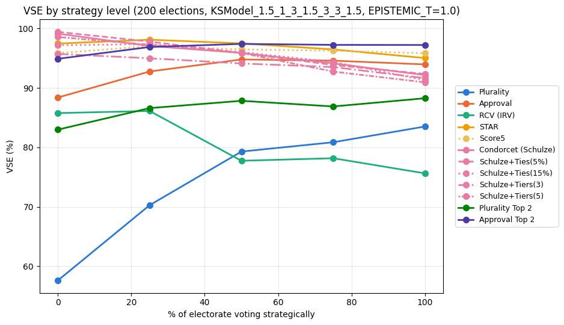

```python
STRATEGY_AXIS = {
    "100% honest": 0,
    "25% strategic": 25,
    "50% strategic": 50,
    "75% strategic": 75,
    "100% strategic": 100,
}

fig, ax = plt.subplots(figsize=(9.5, 5.5))
for label, _ in PRE_NOISE_METHODS:
    points = sorted(
        (STRATEGY_AXIS[chooser_label], mean_)
        for chooser_label, mean_, _ in rows_by_method[label]
        if chooser_label in STRATEGY_AXIS
    )
    if not points:
        continue
    xs, ys = zip(*points)
    ax.plot(xs, [y * 100 for y in ys], marker="o", markersize=7, linewidth=2,
            color=METHOD_COLORS[label], linestyle=METHOD_LINESTYLES[label], label=label)

ax.set_xlabel("% of electorate voting strategically")
ax.set_ylabel("VSE (%)")
ax.set_title(f"VSE by strategy level ({NITER} elections, {MODEL}, EPISTEMIC_T={EPISTEMIC_T})")
ax.legend(fontsize=9, loc="center left", bbox_to_anchor=(1.02, 0.5))
ax.grid(True, alpha=0.3)
plt.tight_layout()
plt.show()
```

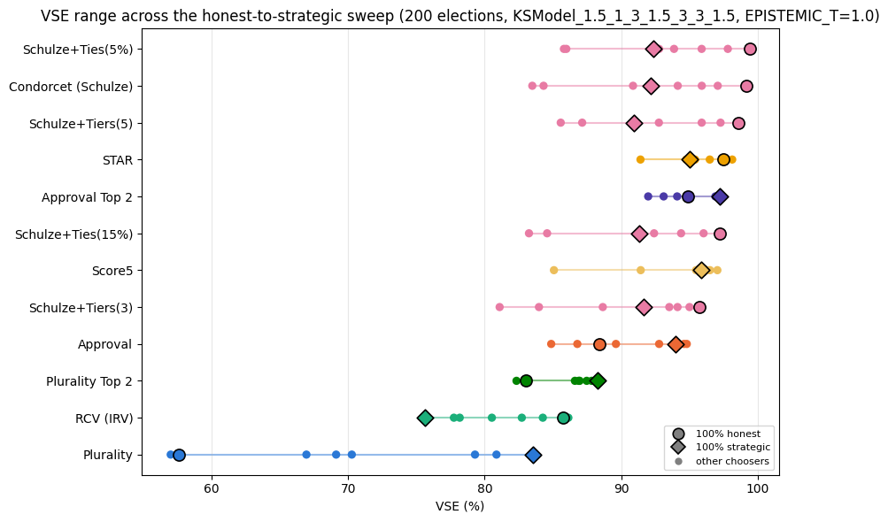

```python
# sort methods by their max VSE across any chooser, so the worst method is at the bottom of the y-axis and the best method is at the top.
_sorted_labels = sorted(
    (label for label, _ in PRE_NOISE_METHODS if rows_by_method[label]),
    key=lambda label: max(mean_ for _, mean_, _ in rows_by_method[label])
)

fig, ax = plt.subplots(figsize=(9, 6))
# _sorted_labels is ascending by max VSE across any chooser; plotting in that order puts the
# worst method at row 0 (the bottom of a matplotlib y-axis) and the best method at the top row,
# as intended.
for row_i, label in enumerate(_sorted_labels):
    vses = [mean_ * 100 for _, mean_, _ in rows_by_method[label]]
    color = METHOD_COLORS[label]
    ax.plot([min(vses), max(vses)], [row_i, row_i], color=color, linewidth=1.5, alpha=0.5, zorder=1)
    for chooser_label, mean_, _ in rows_by_method[label]:
        is_honest = chooser_label == "100% honest"
        is_strategic = chooser_label == "100% strategic"
        ax.scatter(mean_ * 100, row_i,
                   marker="D" if is_strategic else "o",
                   s=90 if (is_honest or is_strategic) else 45,
                   color=color,
                   edgecolors="black" if (is_honest or is_strategic) else "none",
                   linewidths=1.2 if (is_honest or is_strategic) else 0,
                   zorder=3 if (is_honest or is_strategic) else 2)

ax.set_yticks(range(len(_sorted_labels)))
ax.set_yticklabels(_sorted_labels)
ax.set_xlabel("VSE (%)")
ax.set_title(f"VSE range across the honest-to-strategic sweep ({NITER} elections, "
             f"{MODEL}, EPISTEMIC_T={EPISTEMIC_T})")
_marker_legend = [
    Line2D([0], [0], marker="o", linestyle="none", markersize=9,
           markerfacecolor="gray", markeredgecolor="black", markeredgewidth=1.2, label="100% honest"),
    Line2D([0], [0], marker="D", linestyle="none", markersize=8,
           markerfacecolor="gray", markeredgecolor="black", markeredgewidth=1.2, label="100% strategic"),
    Line2D([0], [0], marker="o", linestyle="none", markersize=6,
           markerfacecolor="gray", markeredgecolor="none", label="other choosers"),
]
ax.legend(handles=_marker_legend, fontsize=8, loc="lower right")
ax.grid(True, axis="x", alpha=0.3)
plt.tight_layout()
plt.show()
```